# 写在前面

2023年01月28日，更新ggClusterNet文档。

# R包安装

### 导入R包

```r
#--导入所需R包#-------
library(WGCNA)
library(ggalluvial)
library(ggraph)
library(phyloseq)
library(igraph)
library(network)
library(sna)
library(tidyverse)
library(ggClusterNet)
library(ggplot2)
library(EasyStat)
```

# 输入方式

### 输入方式一

直接输入phyloseq格式的数据。

```r
#-----导入数据#-------
#data(ps)
```

### 输入方式二

可以从https://github.com/taowenmicro/R-_function下载数据，构造phylsoeq文件。自己的数据也按照网址示例数据进行准备。虽然phylsoeq对象不易用常规手段处理，但是组学数据由于数据量比较大，数据注释内容多样化，所以往往使用诸如phyloseq这类对象进行处理，并简化数据处理过程。ggClusterNet同样使用了phyloseq对象作为微生物网络的分析。

或者直接从网站读取，但是由于github在国外，所以容易失败

# 使用ggCLusterNet进行网络分析的过程

### corMicro函数用于计算网络相关

按照丰度过滤微生物表格，并却计算相关矩阵，按照指定的阈值挑选矩阵中展示的数值。调用了psych包中的corr.test函数，使用三种相关方法。 N参数提取丰度最高的150个OTU； method.scale参数确定微生物组数据的标准化方式，这里我们选用TMM方法标准化微生物数据。

```r
#-提取丰度最高的指定数量的otu进行构建网络


#----------计算相关#----
result = corMicro(ps = ps,
                   N = 150,
                   method.scale = "TMM",  # 可以选择相对丰都，或抽样的方法
                   r.threshold=0.5,
                   p.threshold=0.005,
                   method = "spearman")   # 相关性方法 pearson




#--提取相关矩阵。cor是关系矩阵
cor = result[[1]]
cor[1:10,1:10]
```

```
##             ASV_1 ASV_28 ASV_125 ASV_135     ASV_8   ASV_106 ASV_16 ASV_159
## ASV_1   1.0000000      0       0       0 0.0000000 0.0000000      0       0
## ASV_28  0.6835313      1       0       0 0.0000000 0.0000000      0       0
## ASV_125 0.0000000      0       1       0 0.0000000 0.0000000      0       0
## ASV_135 0.0000000      0       0       1 0.0000000 0.0000000      0       0
## ASV_8   0.0000000      0       0       0 1.0000000 0.0000000      0       0
## ASV_106 0.0000000      0       0       0 0.7582649 1.0000000      0       0
## ASV_16  0.0000000      0       0       0 0.0000000 0.0000000      1       0
## ASV_159 0.0000000      0       0       0 0.0000000 0.7359174      0       1
## ASV_2   0.0000000      0       0       0 0.0000000 0.0000000      0       0
## ASV_97  0.0000000      0       0       0 0.0000000 0.0000000      0       0
##            ASV_2 ASV_97
## ASV_1   0.000000      0
## ASV_28  0.000000      0
## ASV_125 0.000000      0
## ASV_135 0.000000      0
## ASV_8   0.000000      0
## ASV_106 0.000000      0
## ASV_16  0.000000      0
## ASV_159 0.000000      0
## ASV_2   1.000000      0
## ASV_97  0.647393      1
```

```r
#-网络中包含的OTU的phyloseq文件提取
ps_net = result[[3]]
ps_net
```

```
## phyloseq-class experiment-level object
## otu_table()   OTU Table:         [ 150 taxa and 18 samples ]
## sample_data() Sample Data:       [ 18 samples by 11 sample variables ]
## tax_table()   Taxonomy Table:    [ 150 taxa by 7 taxonomic ranks ]
## phy_tree()    Phylogenetic Tree: [ 150 tips and 149 internal nodes ]
```

```r
#-导出otu表格
otu_table = ps_net %>%
  vegan_otu() %>%
  t() %>%
  as.data.frame()

path_1 = "C:/16S/result/ggclusternet/imitate/"
dir.create(path_1)
# 作为一个data.frame，出现，。
write.table(otu_table,file = "C:/16S/result/ggclusternet/imitate/otu_table_new.txt",quote = F,sep = '\t', row.names = T, col.names = T)

otu_table
```

```
##          KO1  KO2  KO3  KO4  KO5  KO6  OE1  OE2  OE3  OE4  OE5  OE6  WT1  WT2
## ASV_1   1113 1968  816 1372 1062 1087 1270 1637 1368  962 1247 1017 2345 2538
## ASV_28   253  303   54  439  132  182  154  263  153  257  242  178  391  450
## ASV_125   12  117   56   87   13   26   45   76   32   47   73   18   27   86
## ASV_135   21   71   24   46    5   69   39   67   34   51   44   40   80   35
## ASV_8    508  504  608  424  190  327  335  535 1578  780  507  516  634  763
## ASV_106   52   31   21   30   19   16   22   46  243  142   41   52   83   30
## ASV_16   231  248  521  270  142  215  160  239  598  283  227  179  426  288
## ASV_159   55   39    6   13    7   15   32   33   53   47   38   21   39   34
## ASV_2   1922 1227 2355 2218 2885 1817  640  494 1218 1264  945  635 1280 1493
## ASV_97    64   23   93   32  188   67   54   21   43   32   46   28   58  118
## ASV_79   102  117  102   95  135  161   46   38   51   63   63   66   55   59
## ASV_30   173  119  171  202  203  284  133  110  215  288  140  100  189  200
## ASV_44   158  101  228  199  373  154   77   37   98   84   87   54  141  208
## ASV_32   178  152  146  140  117  150  216  142  148  160  179  195  192  222
## ASV_111   40   54   36   17   37   28   56   40   41   65   51   59   37   84
## ASV_128   39   38   35   29   16   38   60   35   41   36   42   53   38   51
## ASV_132    6   23  223   69   24   53   53   24   39   21   15    3   27   44
## ASV_3    568  460  899  902 1226  855  607  457 1058 1036  837  674 1041 1796
## ASV_4   1433  400  535  759 1287  506  515  590  439  621  661  428 1123 1448
## ASV_55    41   43   98   91  121   66  109   68  110  136  105   84  123  238
## ASV_136   32   25   20   36   79   31   37   30   42   54   38   32   26   38
## ASV_6    882  673  819  888 1475 1017  245  250  366  380  378  351  557  537
## ASV_17   436  299  341  426  437  584  129  109  196  226  230  185  336  310
## ASV_39   195  136  200  214  354  210   74   78  101  120   92   81  107  168
## ASV_60   119  103  134  140  221  133   56   44   68   68   55   58   87   99
## ASV_14   300  316  352  366  451  357  244  181  303  300  349  250  352  550
## ASV_127   37   65   34   59   49   51   31   27   23   42   45   29   38   55
## ASV_166  122  122  196  119  195  135  107   96  148  104  124  112  142  205
## ASV_150   36   35   39   36   39   45   27   24   28   33   32   37   38   40
## ASV_94    41   18   23   30  375   23   71   97   31   24   31   18   51   32
## ASV_107   65   57   61   70   57   82   50   32   42   34   55   56   35   35
## ASV_123   58   61   40   55   61   58   33   17   40   28   44   40   39   46
## ASV_100   79   18   38   59  295   25   29   55   15  114   72   40   33    7
## ASV_11   315  344  321  352  560  375  472  375  244  418  345  186  421  498
## ASV_57    70   53  102   36  352   80  190  124   68   98   75   37  169   88
## ASV_61    75   80   63   75  189   80  119   87   69  110   64   46  116  140
## ASV_144   45   15   19   47   48   32   55   47   41   50   28   28   51   37
## ASV_36   194   66  104  247  199  363   63   37  283  182   97   92  249  330
## ASV_38   113   57   83  214  146  210   45   34  214  137  100  138  219  618
```

[output cut: 247 more lines]

```
## ASV_80   107   58   80   53
## ASV_76    42  276   34   49
## ASV_133   51   31   38   39
## ASV_93    34   50  229  224
## ASV_81    92   97   80   95
## ASV_114   69   70   61   82
## ASV_101   72   40   55   71
## ASV_110   69   62   58   35
## ASV_112   71   86   42   36
## ASV_121   43   21   50   49
## ASV_122   52   51   42   58
## ASV_163   41   34   32   38
## ASV_151   45   29   10   25
## ASV_156   32   31   34   36
## ASV_162   46   18   21   33
```

这是网络布局的基础，无论是什么聚类布局，都需要制作一个分组文件，这个文件有两列，一列是节点，一列是分组信息，这个分组信息名称为：group。这个文件信息就是用于对节点进行分组，然后按照分组对节点归类，使用包中可视化函数计算节点位置。

注意分组文件的格式，分为两列，第一列是网络中包含的OTU的名字，第二列是分组信息，同样的分组标记同样的字符。

```r
#--人工构造分组信息：将网络中全部OTU分为8个部分，等分
netClu = data.frame(ID = row.names(otu_table),group =rep(1:8,length(row.names(otu_table)))[1:length(row.names(otu_table))] )
netClu$group = as.factor(netClu$group)
head(netClu)
```

```
##        ID group
## 1   ASV_1     1
## 2  ASV_28     2
## 3 ASV_125     3
## 4 ASV_135     4
## 5   ASV_8     5
## 6 ASV_106     6
```

### PolygonClusterG 根据分组，计算布局位置坐标

不同的模块按照分组聚集成不同的圆，并且圆形的大小一样。如果一个分组只有一个点，则这个点坐落在圆心位置。

```r
#--------计算布局#---------
result2 = PolygonClusterG (cor = cor,nodeGroup =netClu  )
node = result2[[1]]
head(node)
```

```
##                 X1       X2 elements
## ASV_1    0.0000000 9.375000    ASV_1
## ASV_42   0.8924014 5.850987   ASV_42
## ASV_124 -1.5696871 8.525528  ASV_124
## ASV_99   7.1697848 5.150576   ASV_99
## ASV_37   3.5841139 4.552233   ASV_37
## ASV_4    8.6516465 1.485611    ASV_4
```

### nodeadd 节点注释的：用otu表格和分组文件进行注释

nodeadd函数只是提供了简单的用注释函数，用户可以自己在node的表格后面添加各种注释信息。

```r
tax_table = ps_net %>%
  vegan_tax() %>%
  as.data.frame()
write.table(tax_table,file = "C:/16S/result/ggclusternet/imitate/tax_table_new.txt",quote = F,sep = '\t', row.names = T, col.names = T)

#---node节点注释#-----------
nodes = nodeadd(plotcord =node,otu_table = otu_table,tax_table = tax_table)
nodes[1:6,1:6]
```

```
##                X1         X2 elements  Kingdom         Phylum
## ASV_1    0.000000  9.3750000    ASV_1 Bacteria Actinobacteria
## ASV_10   7.191383 -1.8434550   ASV_10 Bacteria Proteobacteria
## ASV_100  1.817625  7.9602853  ASV_100 Bacteria Proteobacteria
## ASV_101 -6.444381 -3.8342098  ASV_101 Bacteria Proteobacteria
## ASV_102  5.782923 -0.7472065  ASV_102 Bacteria Proteobacteria
## ASV_103  4.408787  3.6563987  ASV_103 Bacteria Proteobacteria
##                       Class
## ASV_1        Actinobacteria
## ASV_10  Alphaproteobacteria
## ASV_100  Betaproteobacteria
## ASV_101          Unassigned
## ASV_102 Gammaproteobacteria
## ASV_103 Alphaproteobacteria
```

### 计算边

```r
#-----计算边#--------
edge = edgeBuild(cor = cor,node = node)
edge[1:20,1:8]
```

```
##           X2        Y2  OTU_2   OTU_1     weight         X1         Y1 cor
## 1  0.0000000  9.375000  ASV_1  ASV_28  0.6835313  5.3011889  7.1804120   +
## 2  0.0000000  9.375000  ASV_1  ASV_86  0.7977296  6.6891141 -6.5668653   +
## 3  0.0000000  9.375000  ASV_1  ASV_21  0.6800826 -5.3180613  3.4134992   +
## 4  0.0000000  9.375000  ASV_1 ASV_108 -0.7070427 -0.2966700 -9.3494179   -
## 5  0.0000000  9.375000  ASV_1  ASV_34  0.7481940 -1.8685959  7.3451637   +
## 6  0.8924014  5.850987 ASV_42  ASV_45  0.7316821  6.1935902  3.6563987   +
## 7  0.8924014  5.850987 ASV_42  ASV_23  0.7234262  0.3086149  5.6505726   +
## 8  3.5841139  4.552233 ASV_37 ASV_119  0.6539260 -1.7051301 -8.2531694   +
## 9  3.5841139  4.552233 ASV_37  ASV_77  0.6952483 -9.3464931 -0.3435077   +
## 10 3.5841139  4.552233 ASV_37  ASV_91 -0.6429309 -9.1237762  0.9195827   -
## 11 7.1913828 -1.843455 ASV_10  ASV_62  0.7958657 -5.6013473 -7.1632757   +
## 12 7.1913828 -1.843455 ASV_10 ASV_134  0.7560725  6.6075963 -1.6430408   +
## 13 7.1913828 -1.843455 ASV_10  ASV_56  0.8124032 -1.3794823  6.2300971   +
## 14 7.1913828 -1.843455 ASV_10  ASV_96  0.8150826  3.9217065  4.0355091   +
## 15 7.1913828 -1.843455 ASV_10  ASV_24  0.7630357  3.9301495 -6.5668653   +
## 16 7.1913828 -1.843455 ASV_10 ASV_140  0.7603536 -6.6722148 -6.5837512   +
## 17 7.1913828 -1.843455 ASV_10  ASV_29  0.6549587 -9.1237762 -0.9554173   +
## 18 7.1913828 -1.843455 ASV_10  ASV_77 -0.6832042 -9.3464931 -0.3435077   -
## 19 7.1913828 -1.843455 ASV_10  ASV_64  0.8022717 -6.9418589  6.2259992   +
## 20 7.1913828 -1.843455 ASV_10  ASV_63  0.8068182  3.7315017  6.3309398   +
```

```r
head(edge)
```

```
##          X2       Y2  OTU_2   OTU_1     weight        X1        Y1 cor
## 1 0.0000000 9.375000  ASV_1  ASV_28  0.6835313  5.301189  7.180412   +
## 2 0.0000000 9.375000  ASV_1  ASV_86  0.7977296  6.689114 -6.566865   +
## 3 0.0000000 9.375000  ASV_1  ASV_21  0.6800826 -5.318061  3.413499   +
## 4 0.0000000 9.375000  ASV_1 ASV_108 -0.7070427 -0.296670 -9.349418   -
## 5 0.0000000 9.375000  ASV_1  ASV_34  0.7481940 -1.868596  7.345164   +
## 6 0.8924014 5.850987 ASV_42  ASV_45  0.7316821  6.193590  3.656399   +
```

### 出图

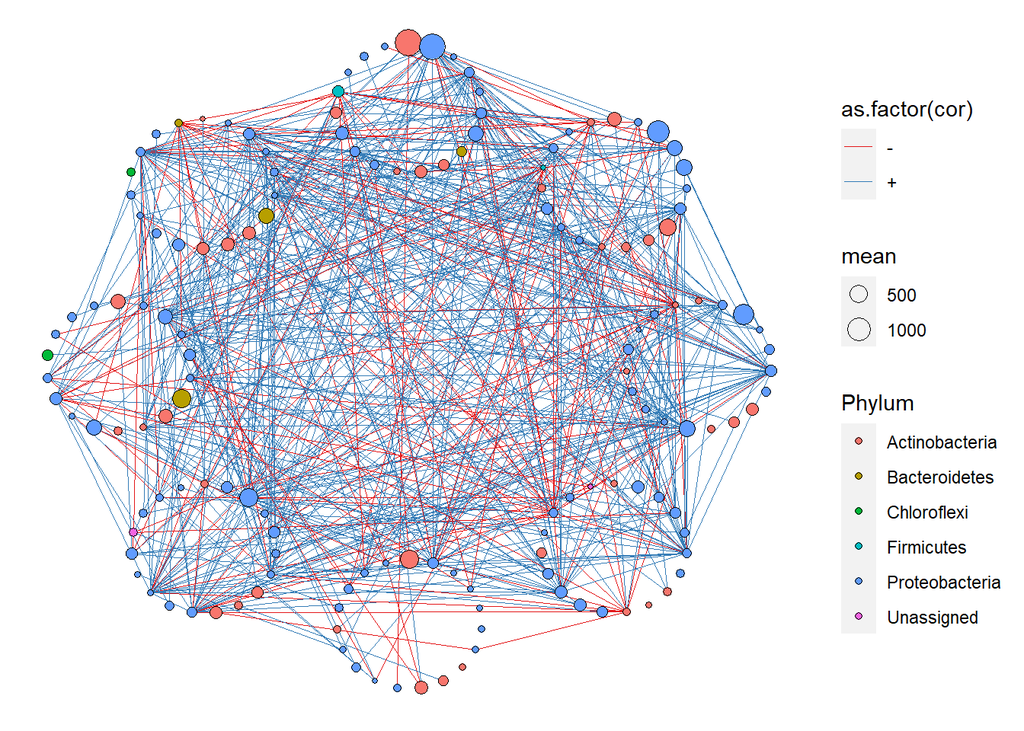

```r
po1 <- ggplot() + geom_segment(aes(x = X1, y = Y1, xend = X2, yend = Y2,color = as.factor(cor)),
                                data = edge, size = 0.3) +
  geom_point(aes(X1, X2,fill = Phylum,size = mean),pch = 21, data = nodes) +
  scale_colour_brewer(palette = "Set1") +
  scale_x_continuous(breaks = NULL) + scale_y_continuous(breaks = NULL) +
  theme(panel.background = element_blank()) +
  theme(axis.title.x = element_blank(), axis.title.y = element_blank()) +
  theme(legend.background = element_rect(colour = NA)) +
  theme(panel.background = element_rect(fill = "white",  colour = NA)) +
  theme(panel.grid.minor = element_blank(), panel.grid.major = element_blank())
po1
```

```r
ggsave("C:/16S/result/ggclusternet/imitate/8group_cs1_new.pdf",po1,width = 8,height = 6)
```

# 模拟不同的分组–可视化

### 模拟不同分组效果展示：1个分组

这是网络布局的基础，无论是什么聚类布局，都需要制作一个分组文件，这个文件有两列，一列是节点，一列是分组信息，这个分组信息名称必须设定为：group。

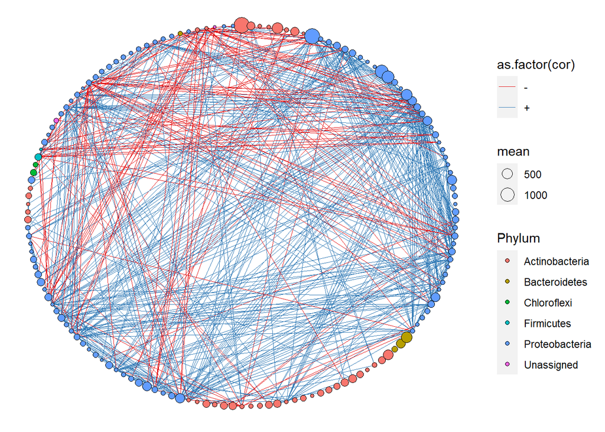

```r
netClu = data.frame(ID = row.names(tax_table),group =rep(1,length(row.names(tax_table)))[1:length(row.names(tax_table))])
netClu$group = as.factor(netClu$group)
result2 = PolygonClusterG (cor = cor,nodeGroup =netClu )
node = result2[[1]]
# ---node节点注释#-----------
nodes = nodeadd(plotcord =node,otu_table = otu_table,tax_table = tax_table)

#-----计算边#--------
edge = edgeBuild(cor = cor,node = node)

### 出图
pnet1 <- ggplot() + geom_segment(aes(x = X1, y = Y1, xend = X2, yend = Y2,color = as.factor(cor)),
                                data = edge, size = 0.3) +
  geom_point(aes(X1, X2,fill = Phylum,size = mean),pch = 21, data = nodes) +
  scale_colour_brewer(palette = "Set1") +
  scale_x_continuous(breaks = NULL) + scale_y_continuous(breaks = NULL) +
  # labs( title = paste(layout,"network",sep = "_"))+
  # geom_text_repel(aes(X1, X2,label=Phylum),size=4, data = plotcord)+
  # discard default grid + titles in ggplot2
  theme(panel.background = element_blank()) +
  # theme(legend.position = "none") +
  theme(axis.title.x = element_blank(), axis.title.y = element_blank()) +
  theme(legend.background = element_rect(colour = NA)) +
  theme(panel.background = element_rect(fill = "white",  colour = NA)) +
  theme(panel.grid.minor = element_blank(), panel.grid.major = element_blank())
pnet1
```

```r
ggsave("C:/16S/result/ggclusternet/imitate/1group_cs2_new.pdf",pnet1,width = 7,height = 5.5)
```

### 模拟不同的分组查看效果：7个分组

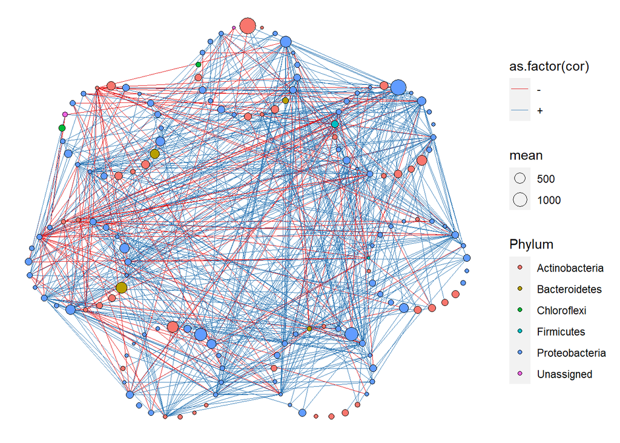

```r
netClu = data.frame(ID = row.names(cor),group =rep(1:7,length(row.names(cor)))[1:length(row.names(cor))] )
netClu$group = as.factor(netClu$group)
result2 = PolygonClusterG (cor = cor,nodeGroup =netClu )
node = result2[[1]]
# ---node节点注释#-----------
nodes = nodeadd(plotcord =node,otu_table = otu_table,tax_table = tax_table)
#-----计算边#--------
edge = edgeBuild(cor = cor,node = node)
### 出图
pnet2 <- ggplot() + geom_segment(aes(x = X1, y = Y1, xend = X2, yend = Y2,color = as.factor(cor)),
                                data = edge, size = 0.25) +
  geom_point(aes(X1, X2,fill = Phylum,size = mean),pch = 21, data = nodes) +
  scale_colour_brewer(palette = "Set1") +
  scale_x_continuous(breaks = NULL) + scale_y_continuous(breaks = NULL) +
  # labs( title = paste(layout,"network",sep = "_"))+
  # geom_text_repel(aes(X1, X2,label=Phylum),size=4, data = plotcord)+
  # discard default grid + titles in ggplot2
  theme(panel.background = element_blank()) +
  # theme(legend.position = "none") +
  theme(axis.title.x = element_blank(), axis.title.y = element_blank()) +
  theme(legend.background = element_rect(colour = NA)) +
  theme(panel.background = element_rect(fill = "white",  colour = NA)) +
  theme(panel.grid.minor = element_blank(), panel.grid.major = element_blank())
pnet2
```

```r
ggsave("C:/16S/result/ggclusternet/imitate/7group_cs3.pdf",pnet2,width = 7,height = 5.5)
```

### 微生物分类分组可视化

```r
#----------计算相关#----
result = corMicro (ps = ps,
                   N = 150,
                   method.scale = "TMM",
                   r.threshold=0.5,
                   p.threshold=0.005,
                   method = "spearman"
                   )

# result = corMicro (ps = ps,
#                    N = 200,
#                    method.scale = "TMM",
#                    r.threshold=0.8,
#                    p.threshold=0.05,
#                    method = "spearman"
#                    )
#

#--提取相关矩阵
cor = result[[1]]
# head(cor)
#-网络中包含的OTU的phyloseq文件提取
ps_net = result[[3]]
#-导出otu表格
otu_table = ps_net %>%
  vegan_otu() %>%
  t() %>%
  as.data.frame()
otu_table
```

```
##          KO1  KO2  KO3  KO4  KO5  KO6  OE1  OE2  OE3  OE4  OE5  OE6  WT1  WT2
## ASV_1   1113 1968  816 1372 1062 1087 1270 1637 1368  962 1247 1017 2345 2538
## ASV_28   253  303   54  439  132  182  154  263  153  257  242  178  391  450
## ASV_125   12  117   56   87   13   26   45   76   32   47   73   18   27   86
## ASV_135   21   71   24   46    5   69   39   67   34   51   44   40   80   35
## ASV_8    508  504  608  424  190  327  335  535 1578  780  507  516  634  763
## ASV_106   52   31   21   30   19   16   22   46  243  142   41   52   83   30
## ASV_16   231  248  521  270  142  215  160  239  598  283  227  179  426  288
## ASV_159   55   39    6   13    7   15   32   33   53   47   38   21   39   34
## ASV_2   1922 1227 2355 2218 2885 1817  640  494 1218 1264  945  635 1280 1493
## ASV_97    64   23   93   32  188   67   54   21   43   32   46   28   58  118
## ASV_79   102  117  102   95  135  161   46   38   51   63   63   66   55   59
## ASV_30   173  119  171  202  203  284  133  110  215  288  140  100  189  200
## ASV_44   158  101  228  199  373  154   77   37   98   84   87   54  141  208
## ASV_32   178  152  146  140  117  150  216  142  148  160  179  195  192  222
## ASV_111   40   54   36   17   37   28   56   40   41   65   51   59   37   84
## ASV_128   39   38   35   29   16   38   60   35   41   36   42   53   38   51
## ASV_132    6   23  223   69   24   53   53   24   39   21   15    3   27   44
## ASV_3    568  460  899  902 1226  855  607  457 1058 1036  837  674 1041 1796
## ASV_4   1433  400  535  759 1287  506  515  590  439  621  661  428 1123 1448
## ASV_55    41   43   98   91  121   66  109   68  110  136  105   84  123  238
## ASV_136   32   25   20   36   79   31   37   30   42   54   38   32   26   38
## ASV_6    882  673  819  888 1475 1017  245  250  366  380  378  351  557  537
## ASV_17   436  299  341  426  437  584  129  109  196  226  230  185  336  310
## ASV_39   195  136  200  214  354  210   74   78  101  120   92   81  107  168
## ASV_60   119  103  134  140  221  133   56   44   68   68   55   58   87   99
## ASV_14   300  316  352  366  451  357  244  181  303  300  349  250  352  550
## ASV_127   37   65   34   59   49   51   31   27   23   42   45   29   38   55
## ASV_166  122  122  196  119  195  135  107   96  148  104  124  112  142  205
## ASV_150   36   35   39   36   39   45   27   24   28   33   32   37   38   40
## ASV_94    41   18   23   30  375   23   71   97   31   24   31   18   51   32
## ASV_107   65   57   61   70   57   82   50   32   42   34   55   56   35   35
## ASV_123   58   61   40   55   61   58   33   17   40   28   44   40   39   46
## ASV_100   79   18   38   59  295   25   29   55   15  114   72   40   33    7
## ASV_11   315  344  321  352  560  375  472  375  244  418  345  186  421  498
## ASV_57    70   53  102   36  352   80  190  124   68   98   75   37  169   88
## ASV_61    75   80   63   75  189   80  119   87   69  110   64   46  116  140
## ASV_144   45   15   19   47   48   32   55   47   41   50   28   28   51   37
## ASV_36   194   66  104  247  199  363   63   37  283  182   97   92  249  330
## ASV_38   113   57   83  214  146  210   45   34  214  137  100  138  219  618
```

[output cut: 247 more lines]

```
## ASV_80   107   58   80   53
## ASV_76    42  276   34   49
## ASV_133   51   31   38   39
## ASV_93    34   50  229  224
## ASV_81    92   97   80   95
## ASV_114   69   70   61   82
## ASV_101   72   40   55   71
## ASV_110   69   62   58   35
## ASV_112   71   86   42   36
## ASV_121   43   21   50   49
## ASV_122   52   51   42   58
## ASV_163   41   34   32   38
## ASV_151   45   29   10   25
## ASV_156   32   31   34   36
## ASV_162   46   18   21   33
```

```r
tax = ps_net %>% vegan_tax() %>%
  as.data.frame()
tax
```

```
##          Kingdom         Phylum               Class              Order
## ASV_1   Bacteria Actinobacteria      Actinobacteria    Actinomycetales
## ASV_28  Bacteria Actinobacteria      Actinobacteria    Actinomycetales
## ASV_125 Bacteria Actinobacteria      Actinobacteria    Actinomycetales
## ASV_135 Bacteria Actinobacteria      Actinobacteria    Actinomycetales
## ASV_8   Bacteria Actinobacteria      Actinobacteria    Actinomycetales
## ASV_106 Bacteria Actinobacteria      Actinobacteria    Actinomycetales
## ASV_16  Bacteria Actinobacteria      Actinobacteria    Actinomycetales
## ASV_159 Bacteria Actinobacteria      Actinobacteria    Actinomycetales
## ASV_2   Bacteria Proteobacteria  Betaproteobacteria    Burkholderiales
## ASV_97  Bacteria Proteobacteria  Betaproteobacteria    Burkholderiales
## ASV_79  Bacteria Proteobacteria  Betaproteobacteria    Burkholderiales
## ASV_30  Bacteria Proteobacteria  Betaproteobacteria    Burkholderiales
## ASV_44  Bacteria Proteobacteria  Betaproteobacteria    Burkholderiales
## ASV_32  Bacteria Proteobacteria  Betaproteobacteria    Burkholderiales
## ASV_111 Bacteria Proteobacteria  Betaproteobacteria    Burkholderiales
## ASV_128 Bacteria Proteobacteria  Betaproteobacteria    Burkholderiales
## ASV_132 Bacteria Proteobacteria  Betaproteobacteria    Burkholderiales
## ASV_3   Bacteria Proteobacteria Gammaproteobacteria    Pseudomonadales
## ASV_4   Bacteria Proteobacteria Gammaproteobacteria    Pseudomonadales
## ASV_55  Bacteria Proteobacteria  Betaproteobacteria    Burkholderiales
## ASV_136 Bacteria Proteobacteria  Betaproteobacteria    Burkholderiales
## ASV_6   Bacteria Proteobacteria  Betaproteobacteria    Burkholderiales
## ASV_17  Bacteria Proteobacteria  Betaproteobacteria    Burkholderiales
## ASV_39  Bacteria Proteobacteria  Betaproteobacteria    Burkholderiales
## ASV_60  Bacteria Proteobacteria  Betaproteobacteria    Burkholderiales
## ASV_14  Bacteria Proteobacteria  Betaproteobacteria    Burkholderiales
## ASV_127 Bacteria Proteobacteria  Betaproteobacteria    Burkholderiales
## ASV_166 Bacteria Proteobacteria  Betaproteobacteria    Burkholderiales
## ASV_150 Bacteria Proteobacteria  Betaproteobacteria    Burkholderiales
## ASV_94  Bacteria Proteobacteria  Betaproteobacteria    Burkholderiales
## ASV_107 Bacteria Proteobacteria  Betaproteobacteria    Burkholderiales
## ASV_123 Bacteria Proteobacteria  Betaproteobacteria    Burkholderiales
## ASV_100 Bacteria Proteobacteria  Betaproteobacteria    Burkholderiales
## ASV_11  Bacteria Proteobacteria  Betaproteobacteria    Burkholderiales
## ASV_57  Bacteria Proteobacteria  Betaproteobacteria    Burkholderiales
## ASV_61  Bacteria Proteobacteria  Betaproteobacteria    Burkholderiales
## ASV_144 Bacteria Proteobacteria  Betaproteobacteria    Burkholderiales
## ASV_36  Bacteria Proteobacteria  Betaproteobacteria    Burkholderiales
## ASV_38  Bacteria Proteobacteria  Betaproteobacteria    Burkholderiales
```

[output cut: 398 more lines]

```
## ASV_80                     Pseudoxanthomonas_wuyuanensis
## ASV_76                                        Unassigned
## ASV_133                                       Unassigned
## ASV_93                             Lysobacter_brunescens
## ASV_81                                        Unassigned
## ASV_114                        Sandaracinus_amylolyticus
## ASV_101                                       Unassigned
## ASV_110                                       Unassigned
## ASV_112                                       Unassigned
## ASV_121                                       Unassigned
## ASV_122                                       Unassigned
## ASV_163                                       Unassigned
## ASV_151                                       Unassigned
## ASV_156                                       Unassigned
## ASV_162                                  Reyranella_soli
```

```r
# 该命令可以往数据中加一列
tax$filed = tax$Phylum
# tax$filed_Class = tax$Class
tax
```

```
##          Kingdom         Phylum               Class              Order
## ASV_1   Bacteria Actinobacteria      Actinobacteria    Actinomycetales
## ASV_28  Bacteria Actinobacteria      Actinobacteria    Actinomycetales
## ASV_125 Bacteria Actinobacteria      Actinobacteria    Actinomycetales
## ASV_135 Bacteria Actinobacteria      Actinobacteria    Actinomycetales
## ASV_8   Bacteria Actinobacteria      Actinobacteria    Actinomycetales
## ASV_106 Bacteria Actinobacteria      Actinobacteria    Actinomycetales
## ASV_16  Bacteria Actinobacteria      Actinobacteria    Actinomycetales
## ASV_159 Bacteria Actinobacteria      Actinobacteria    Actinomycetales
## ASV_2   Bacteria Proteobacteria  Betaproteobacteria    Burkholderiales
## ASV_97  Bacteria Proteobacteria  Betaproteobacteria    Burkholderiales
## ASV_79  Bacteria Proteobacteria  Betaproteobacteria    Burkholderiales
## ASV_30  Bacteria Proteobacteria  Betaproteobacteria    Burkholderiales
## ASV_44  Bacteria Proteobacteria  Betaproteobacteria    Burkholderiales
## ASV_32  Bacteria Proteobacteria  Betaproteobacteria    Burkholderiales
## ASV_111 Bacteria Proteobacteria  Betaproteobacteria    Burkholderiales
## ASV_128 Bacteria Proteobacteria  Betaproteobacteria    Burkholderiales
## ASV_132 Bacteria Proteobacteria  Betaproteobacteria    Burkholderiales
## ASV_3   Bacteria Proteobacteria Gammaproteobacteria    Pseudomonadales
## ASV_4   Bacteria Proteobacteria Gammaproteobacteria    Pseudomonadales
## ASV_55  Bacteria Proteobacteria  Betaproteobacteria    Burkholderiales
## ASV_136 Bacteria Proteobacteria  Betaproteobacteria    Burkholderiales
## ASV_6   Bacteria Proteobacteria  Betaproteobacteria    Burkholderiales
## ASV_17  Bacteria Proteobacteria  Betaproteobacteria    Burkholderiales
## ASV_39  Bacteria Proteobacteria  Betaproteobacteria    Burkholderiales
## ASV_60  Bacteria Proteobacteria  Betaproteobacteria    Burkholderiales
## ASV_14  Bacteria Proteobacteria  Betaproteobacteria    Burkholderiales
## ASV_127 Bacteria Proteobacteria  Betaproteobacteria    Burkholderiales
## ASV_166 Bacteria Proteobacteria  Betaproteobacteria    Burkholderiales
## ASV_150 Bacteria Proteobacteria  Betaproteobacteria    Burkholderiales
## ASV_94  Bacteria Proteobacteria  Betaproteobacteria    Burkholderiales
## ASV_107 Bacteria Proteobacteria  Betaproteobacteria    Burkholderiales
## ASV_123 Bacteria Proteobacteria  Betaproteobacteria    Burkholderiales
## ASV_100 Bacteria Proteobacteria  Betaproteobacteria    Burkholderiales
## ASV_11  Bacteria Proteobacteria  Betaproteobacteria    Burkholderiales
## ASV_57  Bacteria Proteobacteria  Betaproteobacteria    Burkholderiales
## ASV_61  Bacteria Proteobacteria  Betaproteobacteria    Burkholderiales
## ASV_144 Bacteria Proteobacteria  Betaproteobacteria    Burkholderiales
## ASV_36  Bacteria Proteobacteria  Betaproteobacteria    Burkholderiales
## ASV_38  Bacteria Proteobacteria  Betaproteobacteria    Burkholderiales
```

[output cut: 398 more lines]

```
## ASV_80                     Pseudoxanthomonas_wuyuanensis Proteobacteria
## ASV_76                                        Unassigned Proteobacteria
## ASV_133                                       Unassigned Proteobacteria
## ASV_93                             Lysobacter_brunescens Proteobacteria
## ASV_81                                        Unassigned Proteobacteria
## ASV_114                        Sandaracinus_amylolyticus Proteobacteria
## ASV_101                                       Unassigned Proteobacteria
## ASV_110                                       Unassigned Proteobacteria
## ASV_112                                       Unassigned  Bacteroidetes
## ASV_121                                       Unassigned Proteobacteria
## ASV_122                                       Unassigned Actinobacteria
## ASV_163                                       Unassigned Actinobacteria
## ASV_151                                       Unassigned     Unassigned
## ASV_156                                       Unassigned Proteobacteria
## ASV_162                                  Reyranella_soli Proteobacteria
```

```r
dir.create("C:/16S/result/ggclusternet/species_class/")
write.table(tax,file = "C:/16S/result/ggclusternet/species_class/tax_with_filed_new.txt",quote = F,sep = '\t', row.names = T, col.names = T)


group2 <- data.frame(ID = row.names(tax),group = tax$Phylum)  # 原来是Phylum
group2
```

```
##          ID          group
## 1     ASV_1 Actinobacteria
## 2    ASV_28 Actinobacteria
## 3   ASV_125 Actinobacteria
## 4   ASV_135 Actinobacteria
## 5     ASV_8 Actinobacteria
## 6   ASV_106 Actinobacteria
## 7    ASV_16 Actinobacteria
## 8   ASV_159 Actinobacteria
## 9     ASV_2 Proteobacteria
## 10   ASV_97 Proteobacteria
## 11   ASV_79 Proteobacteria
## 12   ASV_30 Proteobacteria
## 13   ASV_44 Proteobacteria
## 14   ASV_32 Proteobacteria
```

[output cut: 136 more lines]

```r
# as.factor又一次出现。
group2$group = as.factor(group2$group)


result2 = PolygonClusterG (cor = cor,nodeGroup =group2)
result2
```

```
## [[1]]
##                    X1        X2 elements
## ASV_1    0.000000e+00 10.000000    ASV_1
## ASV_28   3.910862e-01  9.969221   ASV_28
## ASV_125  7.725425e-01  9.877641  ASV_125
## ASV_135  1.134976e+00  9.727516  ASV_135
## ASV_8    1.469463e+00  9.522542    ASV_8
## ASV_106  1.767767e+00  9.267767  ASV_106
## ASV_16   2.022542e+00  8.969463   ASV_16
## ASV_159  2.227516e+00  8.634976  ASV_159
## ASV_3   -5.147646e+00 -1.652965    ASV_3
## ASV_4   -5.017749e+00 -1.741242    ASV_4
## ASV_55  -4.893653e+00 -1.837501   ASV_55
## ASV_136 -4.775845e+00 -1.941363  ASV_136
## ASV_6   -4.664791e+00 -2.052417    ASV_6
## ASV_17  -4.560930e+00 -2.170224   ASV_17
## ASV_39  -4.464670e+00 -2.294321   ASV_39
## ASV_60  -4.376393e+00 -2.424217   ASV_60
## ASV_14  -4.296446e+00 -2.559400   ASV_14
## ASV_127 -4.225145e+00 -2.699336  ASV_127
## ASV_166 -4.162771e+00 -2.843473  ASV_166
## ASV_150 -4.109571e+00 -2.991242  ASV_150
## ASV_94  -4.065755e+00 -3.142060   ASV_94
## ASV_107 -4.031494e+00 -3.295331  ASV_107
## ASV_123 -4.006926e+00 -3.450451  ASV_123
## ASV_100 -3.992146e+00 -3.606808  ASV_100
## ASV_11  -3.987213e+00 -3.763784   ASV_11
## ASV_57  -3.992146e+00 -3.920761   ASV_57
## ASV_61  -4.006926e+00 -4.077117   ASV_61
## ASV_144 -4.031494e+00 -4.232238  ASV_144
## ASV_36  -4.065755e+00 -4.385509   ASV_36
## ASV_38  -4.109571e+00 -4.536327   ASV_38
## ASV_83  -4.162771e+00 -4.684096   ASV_83
## ASV_50  -4.225145e+00 -4.828233   ASV_50
## ASV_99  -4.296446e+00 -4.968169   ASV_99
## ASV_71  -8.413496e+00 -5.357344   ASV_71
## ASV_140 -8.509755e+00 -5.233247  ASV_140
## ASV_29  -8.598032e+00 -5.103351   ASV_29
## ASV_129 -8.677979e+00 -4.968169  ASV_129
## ASV_33  -8.749280e+00 -4.828233   ASV_33
```

[output cut: 106 more lines]

```
## ASV_114 -7.407524e+00 -1.439343  ASV_114
## ASV_110 -7.108937e+00 -1.342326  ASV_110
## ASV_88  -6.505122e+00  6.232746   ASV_88
## ASV_151 -6.505122e+00  1.232746  ASV_151
## ASV_54  -8.967499e+00 -3.450451   ASV_54
## ASV_162 -6.644189e+00 -1.268717  ASV_162
##
## [[2]]
##            x         y
## 1  0.0000000  7.500000
## 2  6.4931988  3.753448
## 3  6.4991685 -3.743101
## 4  0.0119449 -7.499990
## 5 -6.4872126 -3.763784
## 6 -6.5051217  3.732746
```

```r
node = result2[[1]]
node
```

```
##                    X1        X2 elements
## ASV_1    0.000000e+00 10.000000    ASV_1
## ASV_28   3.910862e-01  9.969221   ASV_28
## ASV_125  7.725425e-01  9.877641  ASV_125
## ASV_135  1.134976e+00  9.727516  ASV_135
## ASV_8    1.469463e+00  9.522542    ASV_8
## ASV_106  1.767767e+00  9.267767  ASV_106
## ASV_16   2.022542e+00  8.969463   ASV_16
## ASV_159  2.227516e+00  8.634976  ASV_159
## ASV_3   -5.147646e+00 -1.652965    ASV_3
## ASV_4   -5.017749e+00 -1.741242    ASV_4
## ASV_55  -4.893653e+00 -1.837501   ASV_55
## ASV_136 -4.775845e+00 -1.941363  ASV_136
## ASV_6   -4.664791e+00 -2.052417    ASV_6
## ASV_17  -4.560930e+00 -2.170224   ASV_17
## ASV_39  -4.464670e+00 -2.294321   ASV_39
## ASV_60  -4.376393e+00 -2.424217   ASV_60
## ASV_14  -4.296446e+00 -2.559400   ASV_14
## ASV_127 -4.225145e+00 -2.699336  ASV_127
## ASV_166 -4.162771e+00 -2.843473  ASV_166
## ASV_150 -4.109571e+00 -2.991242  ASV_150
## ASV_94  -4.065755e+00 -3.142060   ASV_94
## ASV_107 -4.031494e+00 -3.295331  ASV_107
## ASV_123 -4.006926e+00 -3.450451  ASV_123
## ASV_100 -3.992146e+00 -3.606808  ASV_100
## ASV_11  -3.987213e+00 -3.763784   ASV_11
## ASV_57  -3.992146e+00 -3.920761   ASV_57
## ASV_61  -4.006926e+00 -4.077117   ASV_61
## ASV_144 -4.031494e+00 -4.232238  ASV_144
## ASV_36  -4.065755e+00 -4.385509   ASV_36
## ASV_38  -4.109571e+00 -4.536327   ASV_38
## ASV_83  -4.162771e+00 -4.684096   ASV_83
## ASV_50  -4.225145e+00 -4.828233   ASV_50
## ASV_99  -4.296446e+00 -4.968169   ASV_99
## ASV_71  -8.413496e+00 -5.357344   ASV_71
## ASV_140 -8.509755e+00 -5.233247  ASV_140
## ASV_29  -8.598032e+00 -5.103351   ASV_29
## ASV_129 -8.677979e+00 -4.968169  ASV_129
## ASV_33  -8.749280e+00 -4.828233   ASV_33
## ASV_121 -6.955666e+00 -1.308066  ASV_121
```

[output cut: 96 more lines]

```
## ASV_66  -8.509755e+00 -2.294321   ASV_66
## ASV_67  -8.413496e+00 -2.170224   ASV_67
## ASV_90  -8.309634e+00 -2.052417   ASV_90
## ASV_70  -8.198580e+00 -1.941363   ASV_70
## ASV_80  -8.080773e+00 -1.837501   ASV_80
## ASV_76  -7.956676e+00 -1.741242   ASV_76
## ASV_133 -7.826780e+00 -1.652965  ASV_133
## ASV_93  -7.691597e+00 -1.573018   ASV_93
## ASV_81  -7.551661e+00 -1.501717   ASV_81
## ASV_114 -7.407524e+00 -1.439343  ASV_114
## ASV_110 -7.108937e+00 -1.342326  ASV_110
## ASV_88  -6.505122e+00  6.232746   ASV_88
## ASV_151 -6.505122e+00  1.232746  ASV_151
## ASV_54  -8.967499e+00 -3.450451   ASV_54
## ASV_162 -6.644189e+00 -1.268717  ASV_162
```

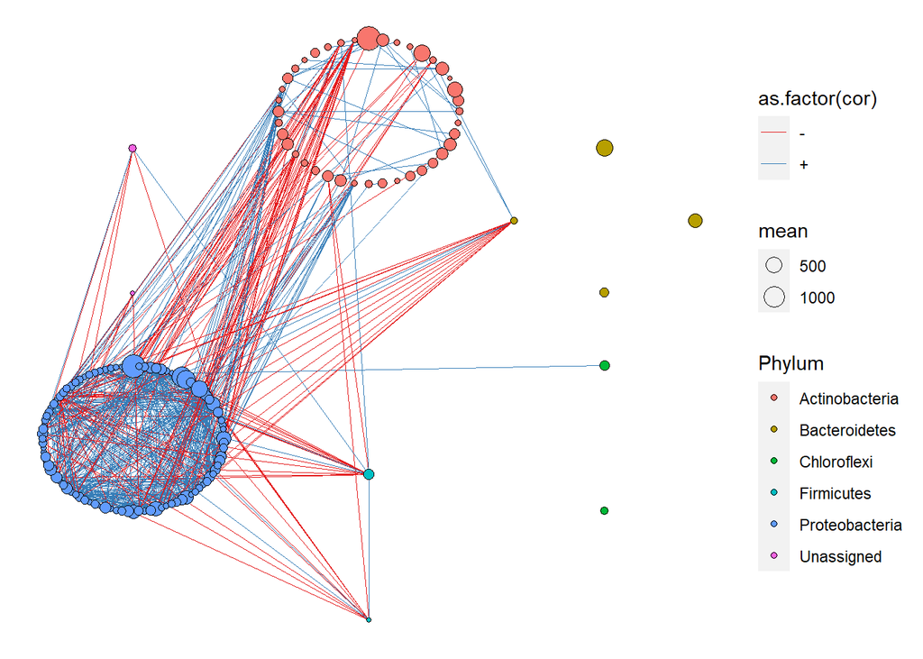

```r
# ---node节点注释#-----------
nodes = nodeadd(plotcord =node,otu_table = otu_table,tax_table = tax_table)
#-----计算边#--------
edge = edgeBuild(cor = cor,node = node)
### 出图
pnet3 <- ggplot() + geom_segment(aes(x = X1, y = Y1, xend = X2, yend = Y2,color = as.factor(cor)),
                                data = edge, size = 0.2) +
  geom_point(aes(X1, X2,fill = Phylum,size = mean),pch = 21, data = nodes) +     # fill = Phylum,
  scale_colour_brewer(palette = "Set1") +
  scale_x_continuous(breaks = NULL) + scale_y_continuous(breaks = NULL) +
  # labs( title = paste(layout,"network",sep = "_"))+
  # geom_text_repel(aes(X1, X2,label=Phylum),size=4, data = plotcord)+
  # discard default grid + titles in ggplot2
  theme(panel.background = element_blank()) +
  # theme(legend.position = "none") +
  theme(axis.title.x = element_blank(), axis.title.y = element_blank()) +
  theme(legend.background = element_rect(colour = NA)) +
  theme(panel.background = element_rect(fill = "white",  colour = NA)) +
  theme(panel.grid.minor = element_blank(), panel.grid.major = element_blank())
pnet3
```

```r
path_2 = "C:/16S/result/ggclusternet/species_class/"
dir.create(path_2)

ggsave("C:/16S/result/ggclusternet/species_class/raw_group_Phylum_cs1_new.pdf",pnet3,width = 7,height = 5.5)
#ggsave("./species_class/raw_group_Class_cs1.pdf",pnet3,width = 7,height = 5.5)
```

### 微生物分类可视化布局优化1-圆环半径调整PolygonRrClusterG

结果发现这些高丰度OTU大部分属于放线菌门和变形菌门，其他比较少。所以下面我们按照OTU数量的多少，对每个模块的大小进行重新调整。

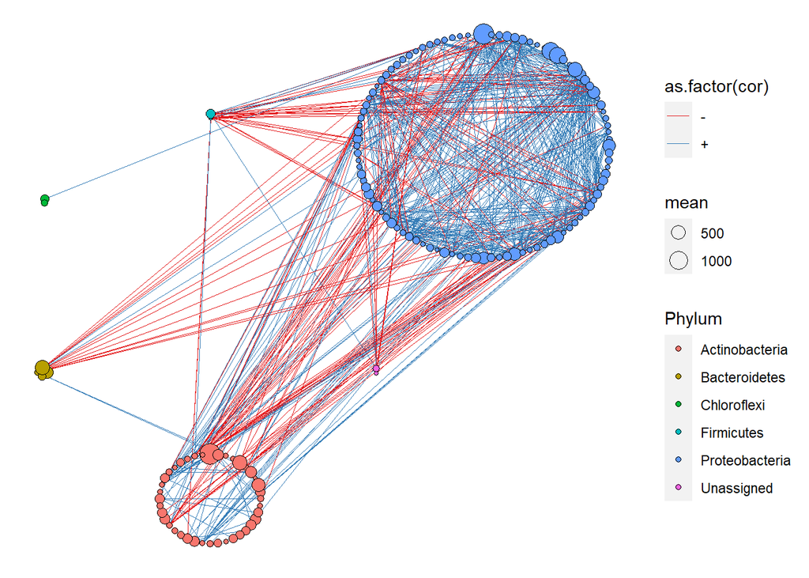

```r
result2 = PolygonRrClusterG(cor = cor,nodeGroup =group2)
node = result2[[1]]
# ---node节点注释#-----------
nodes = nodeadd(plotcord =node,otu_table = otu_table,tax_table = tax_table)
#-----计算边#--------
edge = edgeBuild(cor = cor,node = node)
### 出图
pnet4 <- ggplot() + geom_segment(aes(x = X1, y = Y1, xend = X2, yend = Y2,color = as.factor(cor)),
                                data = edge, size = 0.2) +
  geom_point(aes(X1, X2,fill = Phylum,size = mean),pch = 21, data = nodes) +
  scale_colour_brewer(palette = "Set1") +
  scale_x_continuous(breaks = NULL) + scale_y_continuous(breaks = NULL) +
  # labs( title = paste(layout,"network",sep = "_"))+
  # geom_text_repel(aes(X1, X2,label=Phylum),size=4, data = plotcord)+
  # discard default grid + titles in ggplot2
  theme(panel.background = element_blank()) +
  # theme(legend.position = "none") +
  theme(axis.title.x = element_blank(), axis.title.y = element_blank()) +
  theme(legend.background = element_rect(colour = NA)) +
  theme(panel.background = element_rect(fill = "white",  colour = NA)) +
  theme(panel.grid.minor = element_blank(), panel.grid.major = element_blank())
pnet4
```

```r
ggsave("C:/16S/result/ggclusternet/species_class/optimize1_group_cs2_new.pdf",pnet4,width = 7,height = 5.5)
```

### 微生物分类可视化布局优化2-model_filled_circle

用实心点作为每个模块的布局方式

```r
set.seed(12)
#-实心圆2
result2 = model_filled_circle(cor = cor,
                              culxy =TRUE,
                              da = NULL,# 数据框，包含x,和y列
                              nodeGroup = group2,
                              mi.size = 0.6,# 最小圆圈的半径，越大半径越大
                              zoom = 0.6# 不同模块之间距离
                              )
```

```
## [1] 0
## [1] 1
## [1] 0
## [1] 1
## [1] 2
## [1] 3
```

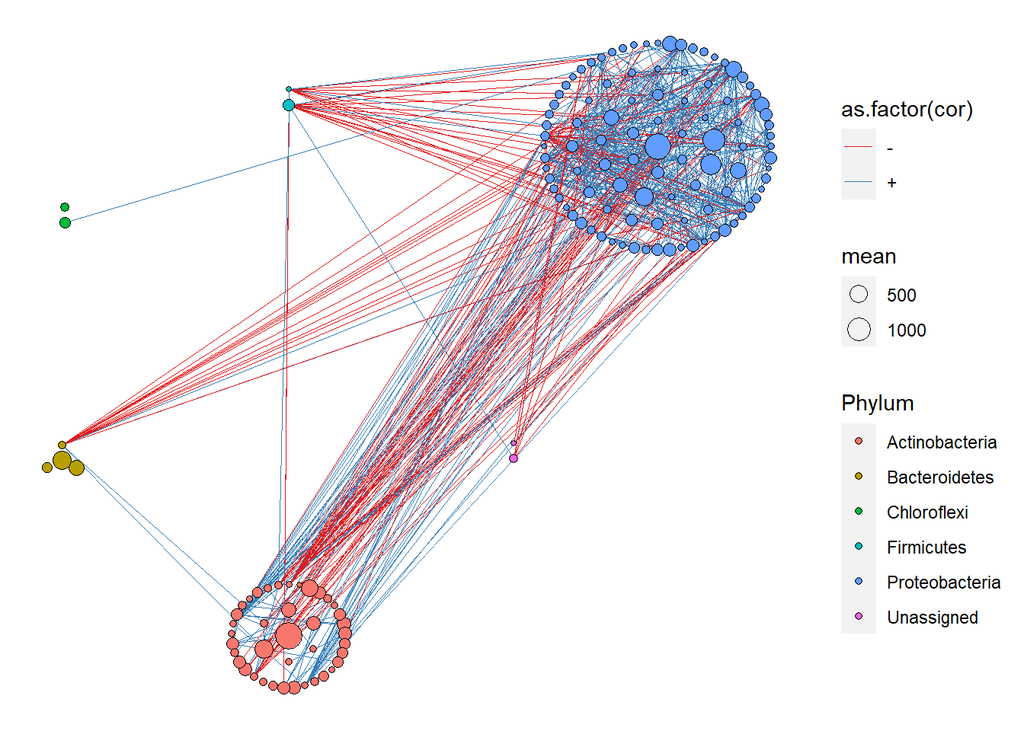

```r
# result2 = model_filled_circle(cor = cor,
#                               culxy =TRUE,
#                               da = NULL,# 数据框，包含x,和y列
#                               nodeGroup = group2,
#                               mi.size = 1,# 最小圆圈的半径，越大半径越大
#                               zoom = 0.3# 不同模块之间距离
#                               )

# result2 = PolygonRrClusterG (cor = cor,nodeGroup =group2 )
node = result2[[1]]
# ---node节点注释#-----------
nodes = nodeadd(plotcord =node,otu_table = otu_table,tax_table = tax_table)
#-----计算边#--------
edge = edgeBuild(cor = cor,node = node)
### 出图
pnet5 <- ggplot() + geom_segment(aes(x = X1, y = Y1, xend = X2, yend = Y2,color = as.factor(cor)),
                                data = edge, size = 0.2) +
  geom_point(aes(X1, X2,fill = Phylum,size = mean),pch = 21, data = nodes) +
  scale_colour_brewer(palette = "Set1") +
  scale_x_continuous(breaks = NULL) + scale_y_continuous(breaks = NULL) +
  # labs( title = paste(layout,"network",sep = "_"))+
  # geom_text_repel(aes(X1, X2,label=Phylum),size=4, data = plotcord)+
  # discard default grid + titles in ggplot2
  theme(panel.background = element_blank()) +
  # theme(legend.position = "none") +
  theme(axis.title.x = element_blank(), axis.title.y = element_blank()) +
  theme(legend.background = element_rect(colour = NA)) +
  theme(panel.background = element_rect(fill = "white",  colour = NA)) +
  theme(panel.grid.minor = element_blank(), panel.grid.major = element_blank())
pnet5
```

```r
ggsave("C:/16S/result/ggclusternet/species_class/optimize2_group_cs3_new.pdf",pnet5,width = 7,height = 5.5)
```

### 微生物分类可视化布局优化3 model_maptree_group

用实心点作为每个模块布局方式2：model_maptree_group，智能布局不同分组之间的距离，在美学上特征更明显一点。

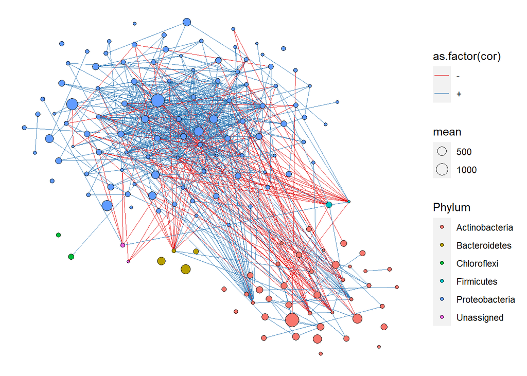

```r
set.seed(12)
#-实心圆2
result2 = model_maptree_group(cor = cor,
                              nodeGroup = group2,
                              )


# result2 = PolygonRrClusterG (cor = cor,nodeGroup =group2 )
node = result2[[1]]
# ---node节点注释#-----------
nodes = nodeadd(plotcord =node,otu_table = otu_table,tax_table = tax_table)
#-----计算边#--------
edge = edgeBuild(cor = cor,node = node)
### 出图
pnet6 <- ggplot() + geom_segment(aes(x = X1, y = Y1, xend = X2, yend = Y2,color = as.factor(cor)),
                                data = edge, size = 0.2) +   # 原本是0.5
  geom_point(aes(X1, X2,fill = Phylum,size = mean),pch = 21, data = nodes) + #pch原本21
  scale_colour_brewer(palette = "Set1") +
  scale_x_continuous(breaks = NULL) + scale_y_continuous(breaks = NULL) +
  # labs( title = paste(layout,"network",sep = "_"))+
  # geom_text_repel(aes(X1, X2,label=Phylum),size=4, data = plotcord)+
  # discard default grid + titles in ggplot2
  theme(panel.background = element_blank()) +
  # theme(legend.position = "none") +
  theme(axis.title.x = element_blank(), axis.title.y = element_blank()) +
  theme(legend.background = element_rect(colour = NA)) +
  theme(panel.background = element_rect(fill = "white",  colour = NA)) +
  theme(panel.grid.minor = element_blank(), panel.grid.major = element_blank())
pnet6
```

```r
ggsave("C:/16S/result/ggclusternet/species_class/optimize3_maptree_group_cs4_new.pdf",pnet6,width = 7,height = 5.5)
```

# 按照网络模块化分组

### 模块布局算法 model_maptree_group

```r
#--modulGroup函数用于计算模块并整理成分组信息
netClu  = modulGroup( cor = cor,cut = NULL,method = "cluster_fast_greedy" )
netClu
```

```
##          ID group
## 1    ASV_28     6
## 2   ASV_125     3
## 3   ASV_135     8
## 4     ASV_8     5
## 5   ASV_106     5
## 6    ASV_16     8
## 7   ASV_159     5
## 8     ASV_2     5
## 9    ASV_97     8
## 10   ASV_79     5
## 11   ASV_30     9
## 12   ASV_44     5
## 13   ASV_32     2
## 14  ASV_111     2
```

[output cut: 136 more lines]

```r
result2 = model_maptree_group(cor = cor,
                              nodeGroup = group2,
                              )
result2
```

```
## [[1]]
##                   X1           X2 elements
## ASV_2    -4.23107008 -14.86240062    ASV_2
## ASV_39    0.75051641  -8.76781968   ASV_39
## ASV_6    -1.21065921  -6.55858810    ASV_6
## ASV_41    0.73216375 -11.41129886   ASV_41
## ASV_17   -3.08614415  -7.81378306   ASV_17
## ASV_60   -5.13177513  -8.50719137   ASV_60
## ASV_73   -4.68808390 -11.19496391   ASV_73
## ASV_10   -2.95559057 -12.84126456   ASV_10
## ASV_64   -0.75335096 -13.24405200   ASV_64
## ASV_66   -4.29797663  -5.42649413   ASV_66
## ASV_44   -4.99923499 -13.09593119   ASV_44
## ASV_140   2.80296979  -9.99226815  ASV_140
## ASV_50   -6.18005910 -10.39571509   ASV_50
## ASV_24    2.15177229  -6.16716670   ASV_24
## ASV_104  -1.92147686 -14.99589858  ASV_104
## ASV_62    0.99046225 -13.57580259   ASV_62
## ASV_56   -6.85504031 -12.20300105   ASV_56
## ASV_63   -7.53526786 -10.25913169   ASV_63
## ASV_79   -2.06529932  -9.92860055   ASV_79
## ASV_47   -7.97730113  -8.24767843   ASV_47
## ASV_96    4.33463745  -8.15764745   ASV_96
## ASV_134  -6.11998015  -6.58654773  ASV_134
## ASV_141   3.51316403 -12.72235444  ASV_141
## ASV_123  -1.92169517  -3.45368889  ASV_123
## ASV_83   -3.21199815 -17.27726627   ASV_83
## ASV_29    2.09514805 -15.31390699   ASV_29
## ASV_14   -0.14206641 -16.92041987   ASV_14
## ASV_98    0.95061598  -3.33696302   ASV_98
## ASV_114  -7.11935679 -15.23720060  ASV_114
## ASV_107  -7.80332694  -5.60986646  ASV_107
## ASV_77   -6.23107384  -4.46287784   ASV_77
## ASV_166   5.95007296 -10.51449562  ASV_166
## ASV_3    -9.24793825 -11.40285269    ASV_3
## ASV_128  -4.31759677  -2.85359485  ASV_128
## ASV_129  -9.96313388  -9.28139276  ASV_129
## ASV_35   -1.52029056 -18.44728424   ASV_35
## ASV_101  -9.63060207 -13.76196425  ASV_101
## ASV_156  -6.00928415 -18.32027540  ASV_156
```

[output cut: 106 more lines]

```
## ASV_12    9.27158334   4.26706674   ASV_12
## ASV_51   11.66613395   2.03016289   ASV_51
## ASV_88   14.89402735  -1.40563670   ASV_88
## ASV_151  12.88303101  -0.97353652  ASV_151
## ASV_40   16.65242067  -3.58185374   ASV_40
## ASV_78   15.50403950  -5.99202233   ASV_78
##
## [[2]]
##                        x          y       elements
## Proteobacteria -1.807650 -10.535805 Proteobacteria
## Actinobacteria  2.684286  15.645242 Actinobacteria
## Firmicutes     -7.491329   7.064145     Firmicutes
## Bacteroidetes  11.091477   4.072538  Bacteroidetes
## Unassigned     13.434631  -1.092058     Unassigned
## Chloroflexi    15.924376  -5.109839    Chloroflexi
```

```r
# result2 = PolygonRrClusterG (cor = cor,nodeGroup =group2 )
node = result2[[1]]

# ---node节点注释#-----------
# 注意nodes里面就有界，门，纲，目，科，属的分类
nodes = nodeadd(plotcord =node,otu_table = otu_table,tax_table = tax_table)
# head(nodes)

nodes2 = nodes %>% inner_join(netClu,by = c("elements" = "ID"))
nodes2
```

```
##               X1           X2 elements  Kingdom         Phylum
## 1     5.88580975  10.79029492    ASV_1 Bacteria Actinobacteria
## 2    -2.95559057 -12.84126456   ASV_10 Bacteria Proteobacteria
## 3    -3.88027983   2.05698337  ASV_100 Bacteria Proteobacteria
## 4    -9.63060207 -13.76196425  ASV_101 Bacteria Proteobacteria
## 5   -15.56940744 -13.95964218  ASV_102 Bacteria Proteobacteria
## 6     8.28955726 -10.00814530  ASV_103 Bacteria Proteobacteria
## 7    -1.92147686 -14.99589858  ASV_104 Bacteria Proteobacteria
## 8    -8.50517586 -19.74657160  ASV_105 Bacteria Proteobacteria
## 9     2.94965510  17.37307965  ASV_106 Bacteria Actinobacteria
## 10   -7.80332694  -5.60986646  ASV_107 Bacteria Proteobacteria
## 11  -13.17586984  -4.30877083  ASV_108 Bacteria Proteobacteria
## 12   -0.02832576  15.53937231  ASV_109 Bacteria Actinobacteria
## 13   -5.01933767 -20.12327917   ASV_11 Bacteria Proteobacteria
## 14  -11.43865152 -20.25812781  ASV_110 Bacteria Proteobacteria
```

[output cut: 589 more lines]

```r
nodes2$group = paste("Model_",nodes2$group,sep = "")
nodes2
```

```
##               X1           X2 elements  Kingdom         Phylum
## 1     5.88580975  10.79029492    ASV_1 Bacteria Actinobacteria
## 2    -2.95559057 -12.84126456   ASV_10 Bacteria Proteobacteria
## 3    -3.88027983   2.05698337  ASV_100 Bacteria Proteobacteria
## 4    -9.63060207 -13.76196425  ASV_101 Bacteria Proteobacteria
## 5   -15.56940744 -13.95964218  ASV_102 Bacteria Proteobacteria
## 6     8.28955726 -10.00814530  ASV_103 Bacteria Proteobacteria
## 7    -1.92147686 -14.99589858  ASV_104 Bacteria Proteobacteria
## 8    -8.50517586 -19.74657160  ASV_105 Bacteria Proteobacteria
## 9     2.94965510  17.37307965  ASV_106 Bacteria Actinobacteria
## 10   -7.80332694  -5.60986646  ASV_107 Bacteria Proteobacteria
## 11  -13.17586984  -4.30877083  ASV_108 Bacteria Proteobacteria
## 12   -0.02832576  15.53937231  ASV_109 Bacteria Actinobacteria
## 13   -5.01933767 -20.12327917   ASV_11 Bacteria Proteobacteria
## 14  -11.43865152 -20.25812781  ASV_110 Bacteria Proteobacteria
```

[output cut: 589 more lines]

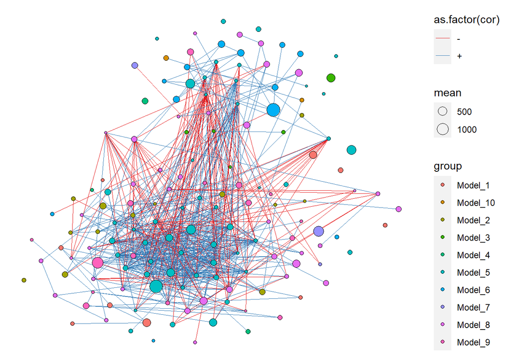

```r
write.table(nodes2,file = "C:/16S/result/ggclusternet/net_model/tax_with_model_new.txt",quote = F,sep = '\t', row.names = T, col.names = T)

#-----计算边#--------
edge = edgeBuild(cor = cor,node = node)

### 出图
pnet7 <- ggplot() + geom_segment(aes(x = X1, y = Y1, xend = X2, yend = Y2,color = as.factor(cor)),
                                data = edge, size = 0.2) +
  geom_point(aes(X1, X2,fill = group,size = mean),pch = 21, data = nodes2) +
  scale_colour_brewer(palette = "Set1") +
  scale_x_continuous(breaks = NULL) + scale_y_continuous(breaks = NULL) +
  # labs( title = paste(layout,"network",sep = "_"))+
  # geom_text_repel(aes(X1, X2,label=Phylum),size=4, data = plotcord)+
  # discard default grid + titles in ggplot2
  theme(panel.background = element_blank()) +
  # theme(legend.position = "none") +
  theme(axis.title.x = element_blank(), axis.title.y = element_blank()) +
  theme(legend.background = element_rect(colour = NA)) +
  theme(panel.background = element_rect(fill = "white",  colour = NA)) +
  theme(panel.grid.minor = element_blank(), panel.grid.major = element_blank())
pnet7
```

```r
path_3 = "C:/16S/result/ggclusternet/net_model/"
dir.create(path_3)

ggsave("C:/16S/result/ggclusternet/net_model/model_maptree_group_cs1_new.pdf",pnet7,width = 7,height = 5.5)
```

### 模块布局算法 model_maptree2

```r
result2 = model_maptree2(cor = cor,
                              method = "cluster_fast_greedy"
                              )

# result2 = PolygonRrClusterG (cor = cor,nodeGroup =group2 )
node = result2[[1]]
node
```

```
##                  X1          X2 elements
## ASV_39    0.3092727  -3.2149711   ASV_39
## ASV_2    -1.2098896  -4.1331698    ASV_2
## ASV_6    -1.3811112  -1.6692014    ASV_6
## ASV_41   -2.1365217  -6.1711713   ASV_41
## ASV_17   -4.3583656  -6.4459559   ASV_17
## ASV_60   -4.2339173  -0.2523496   ASV_60
## ASV_73   -7.0406999  -2.1447364   ASV_73
## ASV_10   -5.5299885  -5.4443586   ASV_10
## ASV_64   -6.9359017  -4.8124526   ASV_64
## ASV_66   -6.1189367  -6.6725221   ASV_66
## ASV_44   -8.5988841  -6.9010363   ASV_44
## ASV_140   0.4781158  -5.7813129  ASV_140
## ASV_24   -3.3065700  -7.5727315   ASV_24
## ASV_62   -3.9396108  -3.7165634   ASV_62
## ASV_104  -1.4610219   1.3151397  ASV_104
## ASV_56   -7.0721758   0.9296478   ASV_56
## ASV_137  -9.9861046  -3.8131931  ASV_137
## ASV_63   -5.2008038  -8.6495974   ASV_63
## ASV_79   -2.3498445  -9.5092483   ASV_79
## ASV_47    0.9761407  -8.9079988   ASV_47
## ASV_96    2.2717822  -3.8393860   ASV_96
## ASV_163   0.9085049  -1.7359851  ASV_163
## ASV_134  -7.8987406 -10.3065014  ASV_134
## ASV_141   0.9064173   0.1902774  ASV_141
## ASV_123  -3.6976334   2.3630073  ASV_123
## ASV_112  -5.8688726   3.5403676  ASV_112
## ASV_120  -8.4840139  -0.4098580  ASV_120
## ASV_98  -10.0727436  -0.9935760   ASV_98
## ASV_109   2.5032556  -1.7929848  ASV_109
## ASV_122  -4.5109191 -10.9056552  ASV_122
## ASV_107   2.9645967  -6.1267091  ASV_107
## ASV_106  -9.8629558   1.6190994  ASV_106
## ASV_156   2.4808010  -0.4310959  ASV_156
## ASV_74  -11.3510564  -6.2819283   ASV_74
## ASV_85    3.8063633  -8.2206018   ASV_85
## ASV_8    -2.0857551   4.2344521    ASV_8
## ASV_54    0.6893440   2.1042708   ASV_54
## ASV_15   -5.9345674 -12.4570127   ASV_15
## ASV_22  -12.6478430  -1.8823088   ASV_22
```

[output cut: 96 more lines]

```
## ASV_75  -10.1484909 -16.6970069   ASV_75
## ASV_7    -5.4978109 -17.0561209    ASV_7
## ASV_12   -3.7905599 -18.0074425   ASV_12
## ASV_51  -15.2733936 -15.1817388   ASV_51
## ASV_9    -7.1681154 -18.0709124    ASV_9
## ASV_31  -19.9272244  -1.9178311   ASV_31
## ASV_117 -19.8111467  -9.5523032  ASV_117
## ASV_154 -17.8597701   3.4191249  ASV_154
## ASV_69   -9.4169471 -19.3210929   ASV_69
## ASV_116  -3.0746351 -20.5794347  ASV_116
## ASV_126 -12.2441065 -16.9016518  ASV_126
## ASV_65   -5.7198351 -19.5993001   ASV_65
## ASV_102 -13.3563745  11.1194349  ASV_102
## ASV_53  -14.2811112 -18.0917569   ASV_53
## ASV_78  -18.2102057 -13.9484076   ASV_78
```

```r
# ---node节点注释#-----------
nodes = nodeadd(plotcord =node,otu_table = otu_table,tax_table = tax_table)
head(nodes)
```

```
##                 X1        X2 elements  Kingdom         Phylum
## ASV_1    -9.812420  9.673996    ASV_1 Bacteria Actinobacteria
## ASV_10   -5.529988 -5.444359   ASV_10 Bacteria Proteobacteria
## ASV_100   9.042478 18.958563  ASV_100 Bacteria Proteobacteria
## ASV_101   7.978404  7.985108  ASV_101 Bacteria Proteobacteria
## ASV_102 -13.356375 11.119435  ASV_102 Bacteria Proteobacteria
## ASV_103   5.548239  6.919623  ASV_103 Bacteria Proteobacteria
##                       Class           Order              Family           Genus
## ASV_1        Actinobacteria Actinomycetales Thermomonosporaceae      Unassigned
## ASV_10  Alphaproteobacteria     Rhizobiales        Rhizobiaceae       Rhizobium
## ASV_100  Betaproteobacteria Burkholderiales      Comamonadaceae  Hydrogenophaga
## ASV_101          Unassigned      Unassigned          Unassigned      Unassigned
## ASV_102 Gammaproteobacteria      Unassigned          Unassigned      Unassigned
## ASV_103 Alphaproteobacteria     Rhizobiales  Phyllobacteriaceae Phyllobacterium
##                              Species       mean
## ASV_1                     Unassigned 1473.61111
## ASV_10                    Unassigned  428.27778
## ASV_100    Hydrogenophaga_intermedia   61.00000
## ASV_101                   Unassigned   60.72222
## ASV_102                   Unassigned   64.00000
## ASV_103 Phyllobacterium_bourgognense   53.77778
```

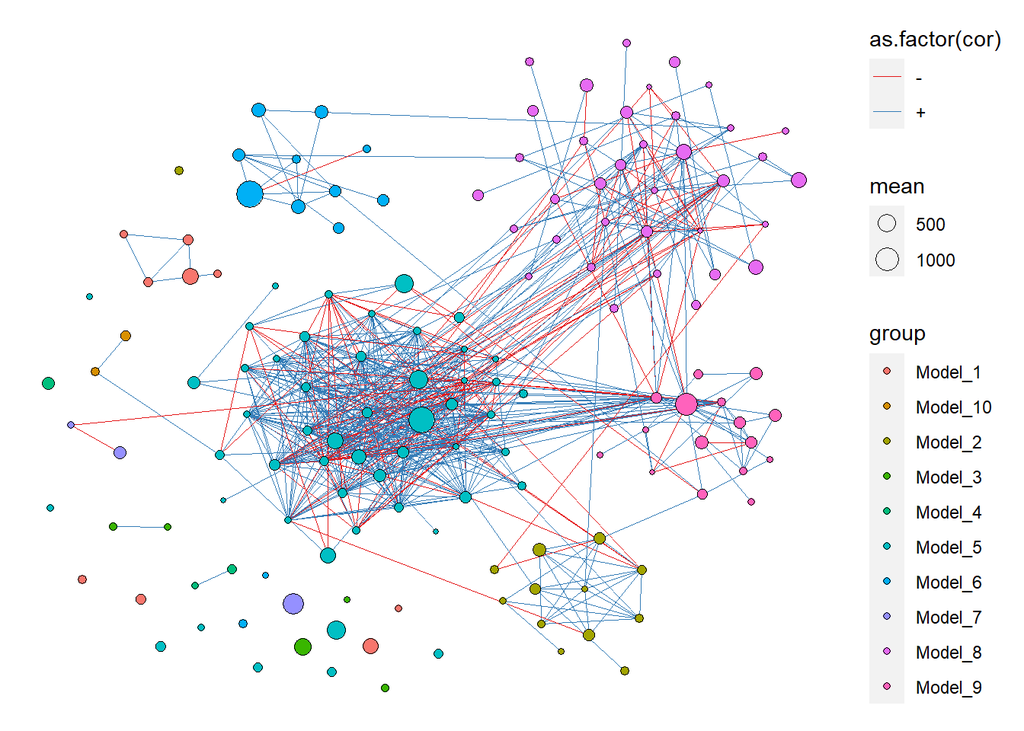

```r
nodes2 = nodes %>% inner_join(netClu,by = c("elements" = "ID"))
nodes2$group = paste("Model_",nodes2$group,sep = "")

#-----计算边#--------
edge = edgeBuild(cor = cor,node = node)

### 出图
pnet8 <- ggplot() + geom_segment(aes(x = X1, y = Y1, xend = X2, yend = Y2,color = as.factor(cor)),
                                data = edge, size = 0.2) +
  geom_point(aes(X1, X2,fill = group,size = mean),pch = 21, data = nodes2) +
  scale_colour_brewer(palette = "Set1") +
  scale_x_continuous(breaks = NULL) + scale_y_continuous(breaks = NULL) +
  # labs( title = paste(layout,"network",sep = "_"))+
  # geom_text_repel(aes(X1, X2,label=Phylum),size=4, data = plotcord)+
  # discard default grid + titles in ggplot2
  theme(panel.background = element_blank()) +
  # theme(legend.position = "none") +
  theme(axis.title.x = element_blank(), axis.title.y = element_blank()) +
  theme(legend.background = element_rect(colour = NA)) +
  theme(panel.background = element_rect(fill = "white",  colour = NA)) +
  theme(panel.grid.minor = element_blank(), panel.grid.major = element_blank())
pnet8
```

```r
ggsave("C:/16S/result/ggclusternet/net_model/model_maptree2_group_cs2_new.pdf",pnet8,width = 7,height = 5.5)
```

### 上千OTU相关性计算测试model_igraph2布局

这个布局最近几年文章上使用非常多。

```r
# cor_Big_micro2 增加了标准化方法和p值矫正方法
result = cor_Big_micro2(ps = ps,
                       N = 1000,
                       r.threshold=0.75,  # 原本是0.85
                       p.threshold=0.05,
                       method = "pearson",
                       scale = FALSE)


#--提取相关矩阵
cor = result[[1]]
dim(cor)
```

```
## [1] 1000 1000
```

```r
# model_igraph2
result2 <- model_igraph2(cor = cor,
                         method = "cluster_fast_greedy",
                         seed = 12)

node = result2[[1]]
dim(node)
```

```
## [1] 707   3
```

```r
dat = result2[[2]]
head(dat)
```

```
##   orig_model    model   color      OTU         X1         X2
## 1         14 model_14 #50A9AF    ASV_1  18.714258  11.607170
## 2         25 model_25 #EBF7A0 ASV_1591 -21.002743 -10.721915
## 3         14 model_14 #50A9AF   ASV_28  16.961106  12.732844
## 4          6  model_6 #F99655 ASV_1480  -1.113763   4.593319
## 5         25 model_25 #EBF7A0  ASV_434 -22.278610  -8.099522
## 6         25 model_25 #EBF7A0  ASV_688 -21.939882  -9.710266
```

```r
tem = data.frame(mod = dat$model,col = dat$color) %>%
  dplyr::distinct(mod, .keep_all = TRUE)
col = tem$col
names(col) = tem$mod

write.table(dat,file = "C:/16S/result/ggclusternet/igraphi/tax_with_modelname_new.txt",quote = F,sep = '\t', row.names = T, col.names = T)
write.table(tem,file = "C:/16S/result/ggclusternet/igraphi/tax_with_color_new.txt",quote = F,sep = '\t', row.names = T, col.names = T)

#---node节点注释#-----------
otu_table = as.data.frame(t(vegan_otu(ps)))
tax_table = as.data.frame(vegan_tax(ps))
nodes = nodeadd(plotcord =node,otu_table = otu_table,tax_table = tax_table)
head(nodes)
```

```
##                  X1          X2 elements  Kingdom         Phylum
## ASV_1     18.714258  11.6071700    ASV_1 Bacteria Actinobacteria
## ASV_10    -6.055203  -3.3908358   ASV_10 Bacteria Proteobacteria
## ASV_100  -11.967075   1.5165039  ASV_100 Bacteria Proteobacteria
## ASV_1002   4.139271  17.7984674 ASV_1002 Bacteria     Firmicutes
## ASV_1006 -12.364454 -20.7573726 ASV_1006 Bacteria Actinobacteria
## ASV_101    3.234638  -0.5862089  ASV_101 Bacteria Proteobacteria
##                        Class           Order              Family          Genus
## ASV_1         Actinobacteria Actinomycetales Thermomonosporaceae     Unassigned
## ASV_10   Alphaproteobacteria     Rhizobiales        Rhizobiaceae      Rhizobium
## ASV_100   Betaproteobacteria Burkholderiales      Comamonadaceae Hydrogenophaga
## ASV_1002             Bacilli      Bacillales  Paenibacillaceae_2     Unassigned
## ASV_1006      Actinobacteria Actinomycetales  Micromonosporaceae     Unassigned
## ASV_101           Unassigned      Unassigned          Unassigned     Unassigned
##                            Species        mean
## ASV_1                   Unassigned 1473.611111
## ASV_10                  Unassigned  428.277778
## ASV_100  Hydrogenophaga_intermedia   61.000000
## ASV_1002                Unassigned    5.666667
## ASV_1006                Unassigned    4.555556
## ASV_101                 Unassigned   60.722222
```

```r
write.table(nodes,file = "C:/16S/result/ggclusternet/igraphi/nodes_with_class_new.txt",quote = F,sep = '\t', row.names = T, col.names = T)
#-----计算边#--------
edge = edgeBuild(cor = cor,node = node)
colnames(edge)[8] = "cor"
head(edge)
```

```
##          X2        Y2    OTU_2   OTU_1    weight        X1         Y1 cor
## 1  18.71426  11.60717    ASV_1  ASV_34 0.8193169  17.92625  12.328467   +
## 2  18.71426  11.60717    ASV_1 ASV_356 0.7593007  18.83128  10.617016   +
## 3 -21.00274 -10.72191 ASV_1591 ASV_688 0.8004402 -21.93988  -9.710266   +
## 4 -21.00274 -10.72191 ASV_1591 ASV_596 0.7603454 -21.57992  -9.053665   +
## 5 -21.00274 -10.72191 ASV_1591 ASV_710 0.9060991 -20.22913 -11.499271   +
## 6 -21.00274 -10.72191 ASV_1591  ASV_20 0.8334483 -21.19987  -9.837729   +
```

```r
tem2 = dat %>%
  dplyr::select(OTU,model,color) %>%
  dplyr::right_join(edge,by =c("OTU" = "OTU_1" ) ) %>%
  dplyr::rename(OTU_1 = OTU,model1 = model,color1 = color)
head(tem2)
```

```
##     OTU_1   model1  color1         X2          Y2    OTU_2    weight         X1
## 1 ASV_688 model_25 #EBF7A0 -21.002743 -10.7219148 ASV_1591 0.8004402 -21.939882
## 2 ASV_688 model_25 #EBF7A0 -22.278610  -8.0995218  ASV_434 0.8002275 -21.939882
## 3 ASV_208 model_25 #EBF7A0 -22.278610  -8.0995218  ASV_434 0.8447586 -22.592299
## 4 ASV_716 model_11 #FDD07D   3.135955 -22.8390507  ASV_174 0.9172530   2.511192
## 5 ASV_106  model_8 #F8FCB4  22.758217  -0.6063897    ASV_8 0.8734179  22.091934
## 6 ASV_340  model_6 #F99655  12.465624   0.8005408  ASV_266 0.7949254   9.441490
##            Y1 cor
## 1  -9.7102660   +
## 2  -9.7102660   +
## 3  -6.0400465   +
## 4 -23.6688396   +
## 5  -0.8861762   +
## 6   1.0811432   +
```

```r
tem3 = dat %>%
  dplyr::select(OTU,model,color) %>%
  dplyr::right_join(edge,by =c("OTU" = "OTU_2" ) ) %>%
  dplyr::rename(OTU_2 = OTU,model2 = model,color2 = color)
head(tem3)
```

```
##      OTU_2   model2  color2        X2        Y2   OTU_1    weight        X1
## 1    ASV_1 model_14 #50A9AF  18.71426  11.60717  ASV_34 0.8193169  17.92625
## 2    ASV_1 model_14 #50A9AF  18.71426  11.60717 ASV_356 0.7593007  18.83128
## 3 ASV_1591 model_25 #EBF7A0 -21.00274 -10.72191 ASV_688 0.8004402 -21.93988
## 4 ASV_1591 model_25 #EBF7A0 -21.00274 -10.72191 ASV_596 0.7603454 -21.57992
## 5 ASV_1591 model_25 #EBF7A0 -21.00274 -10.72191 ASV_710 0.9060991 -20.22913
## 6 ASV_1591 model_25 #EBF7A0 -21.00274 -10.72191  ASV_20 0.8334483 -21.19987
##           Y1 cor
## 1  12.328467   +
## 2  10.617016   +
## 3  -9.710266   +
## 4  -9.053665   +
## 5 -11.499271   +
## 6  -9.837729   +
```

```r
tem4 = tem2 %>%inner_join(tem3)
head(tem4)
```

```
##     OTU_1   model1  color1         X2          Y2    OTU_2    weight         X1
## 1 ASV_688 model_25 #EBF7A0 -21.002743 -10.7219148 ASV_1591 0.8004402 -21.939882
## 2 ASV_688 model_25 #EBF7A0 -22.278610  -8.0995218  ASV_434 0.8002275 -21.939882
## 3 ASV_208 model_25 #EBF7A0 -22.278610  -8.0995218  ASV_434 0.8447586 -22.592299
## 4 ASV_716 model_11 #FDD07D   3.135955 -22.8390507  ASV_174 0.9172530   2.511192
## 5 ASV_106  model_8 #F8FCB4  22.758217  -0.6063897    ASV_8 0.8734179  22.091934
## 6 ASV_340  model_6 #F99655  12.465624   0.8005408  ASV_266 0.7949254   9.441490
##            Y1 cor   model2  color2
## 1  -9.7102660   + model_25 #EBF7A0
## 2  -9.7102660   + model_25 #EBF7A0
## 3  -6.0400465   + model_25 #EBF7A0
## 4 -23.6688396   + model_11 #FDD07D
## 5  -0.8861762   +  model_8 #F8FCB4
## 6   1.0811432   +  model_6 #F99655
```

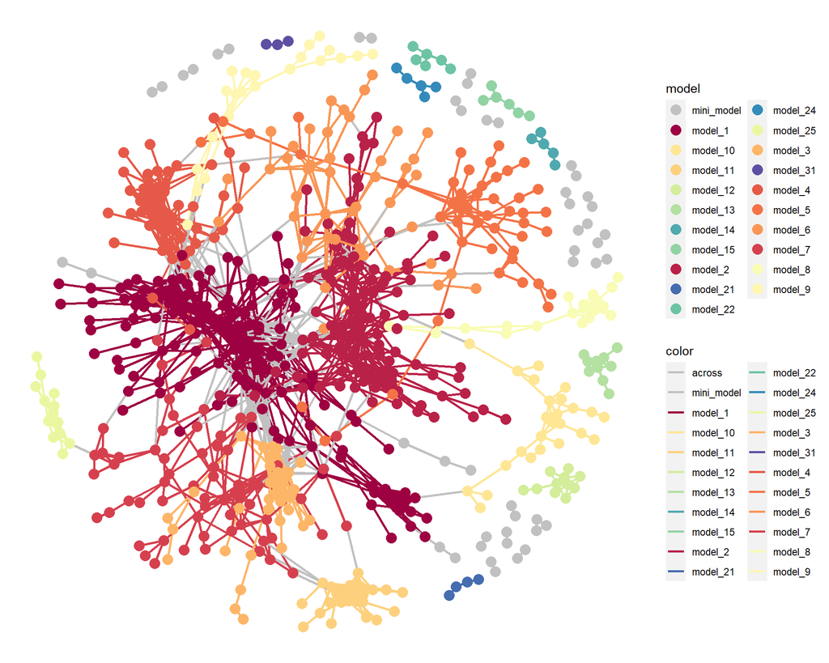

```r
edge2 = tem4 %>% mutate(color = ifelse(model1 == model2,as.character(model1),"across"),
                        manual = ifelse(model1 == model2,as.character(color1),"#C1C1C1")
                        )


col_edge = edge2 %>% dplyr::distinct(color, .keep_all = TRUE)  %>%
  select(color,manual)
col0 = col_edge$manual
names(col0) = col_edge$color

library(ggnewscale)

p1 <- ggplot() + geom_segment(aes(x = X1, y = Y1, xend = X2, yend = Y2,color = color),
                              data = edge2, size = 1) +  # 原本是1
  scale_colour_manual(values = col0)

# ggsave("./cs1.pdf",p1,width = 16,height = 14)
plo1 = p1 +
   new_scale_color() +
  geom_point(aes(X1, X2,color =model), data = dat,size = 4) +  # 原本是4
  scale_colour_manual(values = col) +
  scale_x_continuous(breaks = NULL) + scale_y_continuous(breaks = NULL) +
  theme(panel.background = element_blank()) +
  theme(axis.title.x = element_blank(), axis.title.y = element_blank()) +
  theme(legend.background = element_rect(colour = NA)) +
  theme(panel.background = element_rect(fill = "white",  colour = NA)) +
  theme(panel.grid.minor = element_blank(), panel.grid.major = element_blank())
plo1
```

```r
path_4 = "C:/16S/result/ggclusternet/igraphi/"
dir.create(path_4)

ggsave("C:/16S/result/ggclusternet/igraphi/igraphi_cs1_new.pdf",plo1,width = 12,height = 10)
```

# 网络属性和节点属性

### 网络性质计算

22年6月升级后版本包括了16项网络属性，包括周集中老师21年NCC文章中全部属性

```r
path_5 = "C:/16S/result/ggclusternet/net_node_features/"
dir.create(path_5)

igraph = result2[[3]]
upgrade_graph(igraph)
```

```
## IGRAPH 9cf63e0 UNW- 707 2212 --
## + attr: name (v/c), modularity (v/n), label (v/l), color (v/c),
## | frame.color (v/c), weight (e/n), correlation (e/n), color (e/c)
## + edges from 9cf63e0 (vertex names):
##  [1] ASV_1   --ASV_34   ASV_1   --ASV_356  ASV_1591--ASV_688  ASV_1591--ASV_596
##  [5] ASV_1591--ASV_710  ASV_1591--ASV_20   ASV_1591--ASV_552  ASV_1591--ASV_451
##  [9] ASV_28  --ASV_18   ASV_28  --ASV_34   ASV_1480--ASV_240  ASV_1480--ASV_544
## [13] ASV_1480--ASV_2438 ASV_434 --ASV_688  ASV_434 --ASV_208  ASV_434 --ASV_596
## [17] ASV_434 --ASV_780  ASV_434 --ASV_20   ASV_434 --ASV_93   ASV_688 --ASV_596
## [21] ASV_688 --ASV_780  ASV_688 --ASV_20   ASV_688 --ASV_451  ASV_8   --ASV_106
## [25] ASV_8   --ASV_231  ASV_8   --ASV_454  ASV_8   --ASV_117  ASV_8   --ASV_334
## + ... omitted several edges
```

```r
dat1 = net_properties(igraph)
head(dat1)
```

```
##                       value
## num.edges      2.212000e+03
## num.pos.edges  2.212000e+03
## num.neg.edges  0.000000e+00
## num.vertices   7.070000e+02
## connectance    8.863209e-03
## average.degree 6.257426e+00
```

```r
write.table(dat1,file = "C:/16S/result/ggclusternet/net_node_features/net_feature1_new.txt",quote = F,sep = '\t', row.names = T, col.names = T)


# 升级后包含的网络属性更多, n.hub中T不行跑不出来，F可以
dat2 = net_properties.2(igraph,n.hub = F)
head(dat2,n = 16)
```

```
##                                         value
## num.edges(L)                            "2212"
## num.pos.edges                           "2212"
## num.neg.edges                           "0"
## num.vertices(n)                         "707"
## Connectance(edge_density)               "0.00886320926710235"
## average.degree(Average K)               "6.25742574257426"
## average.path.length                     "5.19822227670119"
## diameter                                "16.0149890640181"
## edge.connectivity                       "0"
## mean.clustering.coefficient(Average.CC) "0.45033020285778"
## no.clusters                             "29"
## centralization.degree                   "0.0364625697697248"
## centralization.betweenness              "0.0845065297601467"
## centralization.closeness                "1.52434741061819"
## RM(relative.modularity)                 "1.45804537017409"
## the.number.of.keystone.nodes            "Not.calculated"
```

```r
write.table(dat2,file = "C:/16S/result/ggclusternet/net_node_features/net_feature2_new.txt",quote = F,sep = '\t', row.names = T, col.names = T)

dat3 = net_properties.3(igraph,n.hub = F)
head(dat3,n = 16)
```

```
##                                         value
## num.edges(L)                            "2212"
## num.pos.edges                           "2212"
## num.neg.edges                           "0"
## num.vertices(n)                         "707"
## Connectance(edge_density)               "0.00886320926710235"
## average.degree(Average K)               "6.25742574257426"
## average.path.length                     "5.19822227670119"
## diameter                                "16.0149890640181"
## edge.connectivity                       "0"
## mean.clustering.coefficient(Average.CC) "0.45033020285778"
## no.clusters                             "29"
## centralization.degree                   "0.0364625697697248"
## centralization.betweenness              "0.0845065297601467"
## centralization.closeness                "1.52434741061819"
## RM(relative.modularity)                 "-121.795868950499"
## the.number.of.keystone.nodes            "Not.calculated"
```

```r
write.table(dat3,file = "C:/16S/result/ggclusternet/net_node_features/net_feature3_new.txt",quote = F,sep = '\t', row.names = T, col.names = T)


# 增加了网络模块性（modularity.net ）和随机网络模块性（modularity_random ）
dat4 = net_properties.4(igraph,n.hub = F)
head(dat4,n = 16)
```

```
##                                         value
## num.edges(L)                            "2212"
## num.pos.edges                           "2212"
## num.neg.edges                           "0"
## num.vertices(n)                         "707"
## Connectance(edge_density)               "0.00886320926710235"
## average.degree(Average K)               "6.25742574257426"
## average.path.length                     "5.19822227670119"
## diameter                                "16.0149890640181"
## edge.connectivity                       "0"
## mean.clustering.coefficient(Average.CC) "0.45033020285778"
## no.clusters                             "29"
## centralization.degree                   "0.0364625697697248"
## centralization.betweenness              "0.0845065297601467"
## centralization.closeness                "1.52434741061819"
## RM(relative.modularity)                 "1.39846154938285"
## modularity.net                          "0.759568574665885"
```

```r
write.table(dat4,file = "C:/16S/result/ggclusternet/net_node_features/net_feature4_new.txt",quote = F,sep = '\t', row.names = T, col.names = T)
```

### 节点性质计算

```r
nodepro = node_properties(igraph)
head(nodepro)
```

```
##          igraph.degree igraph.closeness igraph.betweenness igraph.cen.degree
## ASV_1                2       0.66666667            3.00000                 2
## ASV_1591             6       0.10636458          712.95000                 6
## ASV_28               2       0.57142857            0.00000                 2
## ASV_1480             3       0.18082917           86.54997                 3
## ASV_434              6       0.09636478         1838.00000                 6
## ASV_688              6       0.09636478            6.15000                 6
```

```r
write.table(nodepro,file = "C:/16S/result/ggclusternet/net_node_features/nodes_feature_new.txt",quote = F,sep = '\t', row.names = T, col.names = T)
```

### Zipi基于模块对OTU进行分类

```r
result = cor_Big_micro2(ps = ps,
                       N = 500,
                       r.threshold=0.55,
                       p.threshold=0.05,
                       # method = "pearson",
                       scale = FALSE
)

#--提取相关矩阵
cor = result[[1]]

result4 = nodeEdge(cor = cor)
result4
```

```
## [[1]]
## # A tibble: 1,078 × 4
##    from    to       weight direction
##    <chr>   <chr>     <dbl> <chr>
##  1 ASV_86  ASV_1     0.798 pp
##  2 ASV_539 ASV_1     0.769 pp
##  3 ASV_34  ASV_1     0.748 pp
##  4 ASV_383 ASV_1591  0.787 pp
##  5 ASV_18  ASV_28    0.780 pp
##  6 ASV_20  ASV_28    0.804 pp
##  7 ASV_34  ASV_28    0.741 pp
##  8 ASV_480 ASV_434   0.744 pp
##  9 ASV_106 ASV_8     0.758 pp
## 10 ASV_54  ASV_8    -0.751 np
## # ℹ 1,068 more rows
##
## [[2]]
## # A tibble: 335 × 1
##    name
##  * <chr>
##  1 ASV_86
##  2 ASV_539
##  3 ASV_34
##  4 ASV_383
##  5 ASV_18
##  6 ASV_20
##  7 ASV_480
##  8 ASV_106
##  9 ASV_54
## 10 ASV_334
## # ℹ 325 more rows
```

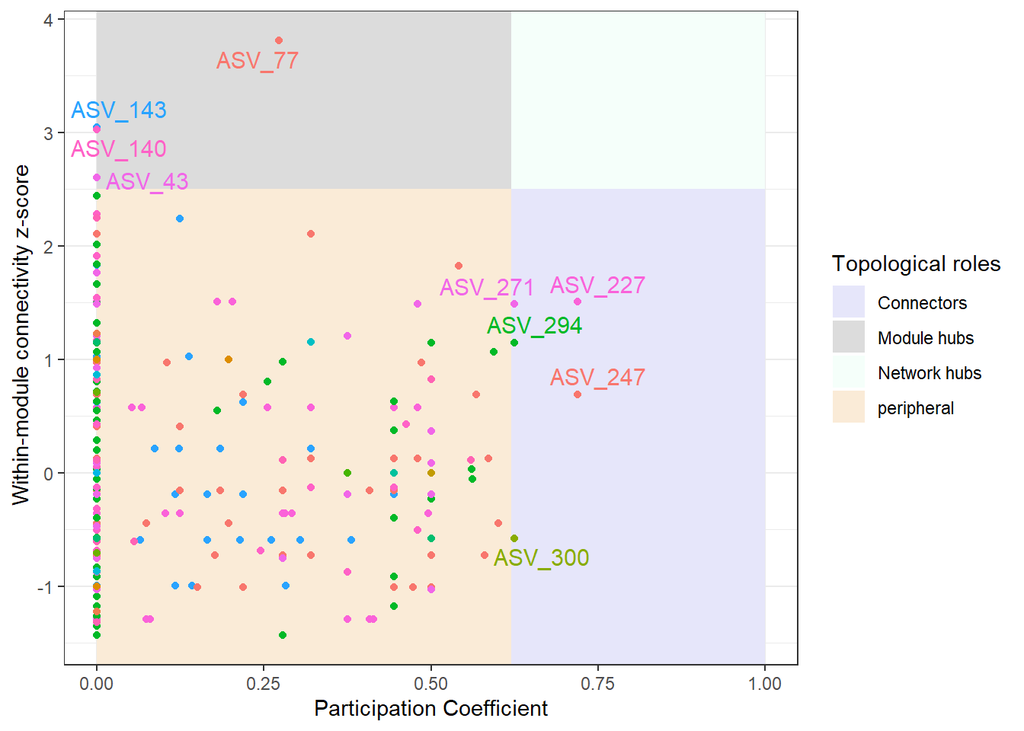

```r
#提取变文件
edge = result4[[1]]
#--提取节点文件
node = result4[[2]]
igraph  = igraph::graph_from_data_frame(edge, directed = FALSE, vertices = node)
res = ZiPiPlot(igraph = igraph,method = "cluster_fast_greedy")  # 按照模块分组进行颜色区分
pA <- res[[1]]
pA
```

```r
dataNN <- res[[2]]
write.table(dataNN,file = "C:/16S/result/ggclusternet/net_node_features/zipi_data_new.txt",quote = F,sep = '\t', row.names = T, col.names = T)
ggsave("C:/16S/result/ggclusternet/net_node_features/zipi_classfication_new.pdf",pA,width = 8,height = 7)
```

### 扩展-关键OTU挑选

Hub节点是在网络中与其他节点连接较多的节点，Hub微生物就是与其他微生物联系较为紧密的微生物，可以称之为关键微生物（keystone）

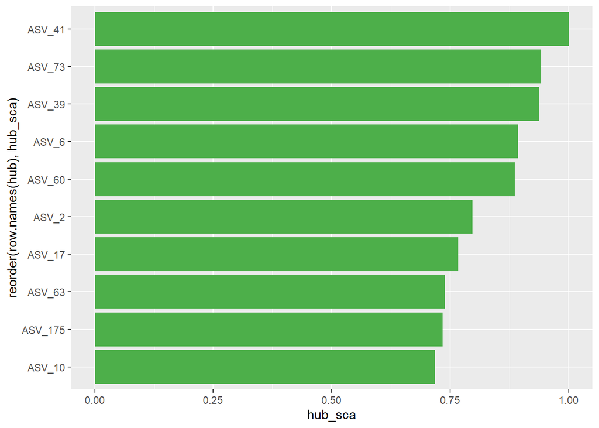

```r
hub = hub_score(igraph)$vector %>%
  sort(decreasing = TRUE) %>%
  head(10) %>%
  as.data.frame()

colnames(hub) = "hub_sca"

ggplot(hub) +
  geom_bar(aes(x = hub_sca,y = reorder(row.names(hub),hub_sca)),stat = "identity",fill = "#4DAF4A")
```

```r
ggsave("C:/16S/result/ggclusternet/net_node_features/top_keystone_micro_new.pdf",width = 5,height = 4)
```

### 对应随机网络构建和网络参数比对

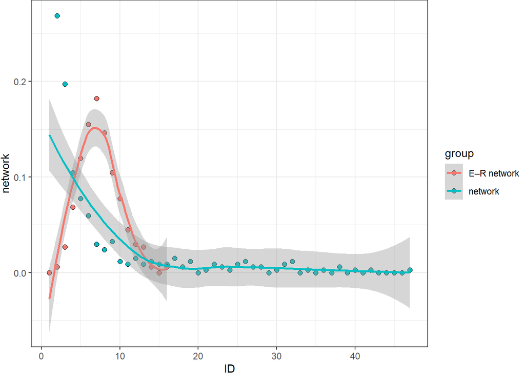

```r
result = random_Net_compate(igraph = igraph, type = "gnm", step = 100, netName = layout)
ppnet = result[[1]]
sum_net = result[[4]]
ppnet
```

```r
head(sum_net)
```

```
##                           KO                   Means                SD
## num.edges(L)              "1078"               "1078"               "0"
## num.pos.edges             "757"                "0"                  "0"
## num.neg.edges             "321"                "0"                  "0"
## num.vertices(n)           "335"                "335"                "0"
## Connectance(edge_density) "0.0192689248368934" "0.0192689248368934" "0"
## average.degree(Average K) "6.43582089552239"   "6.43582089552239"   "0"
```

```r
write.table(sum_net,file = "C:/16S/result/ggclusternet/net_node_features/sum_net_compare_new.txt",quote = F,sep = '\t', row.names = T, col.names = T)
ggsave("C:/16S/result/ggclusternet/net_node_features/randomnet_net_compare_new.pdf",ppnet,width = 5,height = 4)
```

# 微生物网络流程

### 微生物组小网络：model_Gephi.2

使用network函数运行微生物网络全套分析：

- 使用OTU数量建议少于250个，如果OTU数量为250个，同时计算zipi，整个运算过程为3-5min。

```r
# data("ps16s")
path = "C:/16S/result/ggclusternet/result_micro_200_3/"
dir.create(path)

result = network(ps = ps,
                 N = 200,
                 layout_net = "model_Gephi.2",
                 r.threshold=0.8,
                 p.threshold=0.05,
                 label = FALSE,
                 path = path,
                 zipi = TRUE)
```

```
## [1] "KO"
## [1] "cor matrix culculating over"
## [1] "1"
## [1] 0
## [1] 1
## [1] 2
## [1] 3
## [1] 4
## [1] 5
## [1] 6
```

```
## [1] "OE"
## [1] "cor matrix culculating over"
## [1] "1"
## [1] 0
## [1] 1
## [1] 2
## [1] 3
## [1] 4
## [1] 5
## [1] 6
```

```
## [1] "WT"
## [1] "cor matrix culculating over"
## [1] "1"
## [1] 0
## [1] 1
## [1] 2
## [1] 3
## [1] 4
## [1] 5
## [1] 6
```

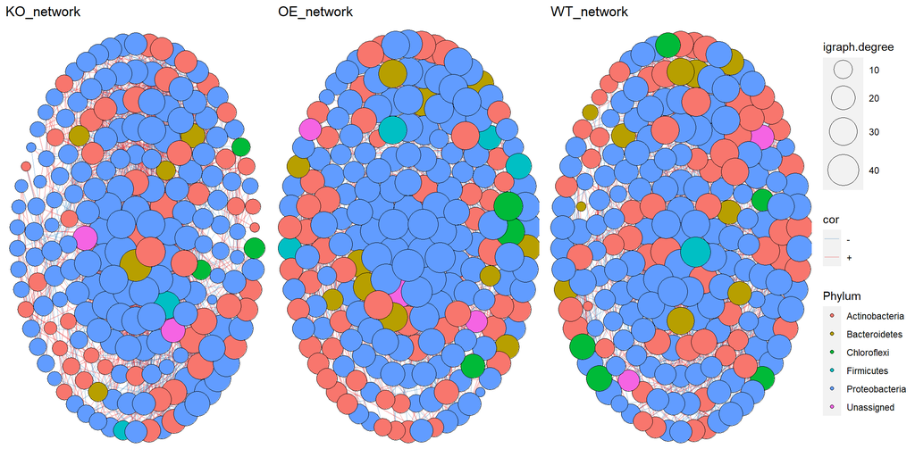

```r
# 多组网络绘制到一个面板
p = result[[1]]
p
```

```r
# 全部样本网络参数比对
data = result[[2]]


plotname1 = paste(path,"/network_all.jpg",sep = "")
ggsave(plotname1, p,width = 48,height = 16,dpi = 72)

plotname1 = paste(path,"/network_all.pdf",sep = "")
ggsave(plotname1, p,width = 48,height = 16)


tablename <- paste(path,"/co-occurrence_Grobel_net",".csv",sep = "")
write.csv(data,tablename)


# write.table(sum_net,file = "./net_node_features/sum_net_compare.txt",quote = F,sep = '\t', row.names = T, col.names = T)
# ggsave("./net_node_features/randomnet_net_compare.pdf",ppnet,width = 5,height = 4)
```

### 微生物大网络：model_maptree2

- 3000个OTU不计算zipi全套需要18min。

```r
path = "./result_big_1000_2/"
dir.create(path)

result = network.2(ps = ps,
                 N = 1000,
                 big = TRUE,
                 maxnode = 5,
                 select_layout = TRUE,
                  layout_net = "model_maptree2",
                 r.threshold=0.6,
                 p.threshold=0.05,
                 label = FALSE,
                 path = path,
                 zipi = TRUE)
```

```
## [1] "KO"
## [1] "cor matrix culculating over"
```

```
## [1] "OE"
## [1] "cor matrix culculating over"
```

```
## [1] "WT"
## [1] "cor matrix culculating over"
```

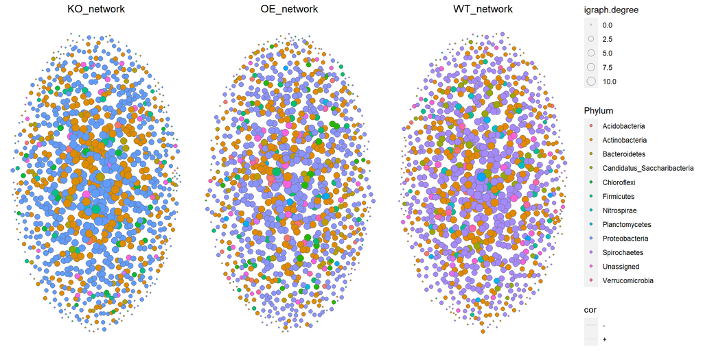

```r
# 多组网络绘制到一个面板
p = result[[1]]
p
```

```r
# 全部样本网络参数比对
data = result[[2]]
num= 3
# plotname1 = paste(path,"/network_all.jpg",sep = "")
# ggsave(plotname1, p,width = 16*num,height = 16,dpi = 72)

plotname1 = paste(path,"/network_all.pdf",sep = "")
ggsave(plotname1, p,width = 10*num,height = 10,limitsize = FALSE)

tablename <- paste(path,"/co-occurrence_Grobel_net",".csv",sep = "")
write.csv(data,tablename)
```

### 微生物大网络：model_igraph

```r
path = "./result_1000_igraph/"
dir.create(path)
# map = sample_data(ps)
# map$Group = "one"
# sample_data(ps16s) = map
result = network.2(ps = ps,
                 N = 1000,
                 big = TRUE,
                 maxnode = 5,
                 select_layout = TRUE,
                  layout_net = "model_igraph",
                 r.threshold=0.6,
                 p.threshold=0.05,
                 label = FALSE,
                 path = path,
                 zipi = FALSE)
```

```
## [1] "KO"
## [1] "cor matrix culculating over"
```

```
## [1] "OE"
## [1] "cor matrix culculating over"
```

```
## [1] "WT"
## [1] "cor matrix culculating over"
```

```r
# 多组网络绘制到一个面板
p = result[[1]]
# 全部样本网络参数比对
data = result[[2]]
num= 18
# plotname1 = paste(path,"/network_all.jpg",sep = "")
# ggsave(plotname1, p,width = 16*num,height = 16,dpi = 72)

plotname1 = paste(path,"/network_all.pdf",sep = "")
ggsave(plotname1, p ,width = 16*num,height = 16,limitsize = FALSE)

ggsave("./result_1000_igraph/network_all.pdf", p ,width = 16*num,height = 16,limitsize = FALSE)
data("ps")

tablename <- paste(path,"/co-occurrence_Grobel_net",".csv",sep = "")
write.csv(data,tablename)
```

### 微生物大网络：model_igraph2-network.i

model_igraph2在model_igraph的基础上去除了离散点，这对于重复数量少的研究比较有利，可以更加清楚的展示小样本网络。

network.i函数专门为model_igraph2算法而写，可以额外输出模块上色的网络。

```r
path = "C:/16S/result/ggclusternet/result_1000_igraph2_500_new/"
dir.create(path)

# map = sample_data(ps)
# map$Group = "one"
# sample_data(ps16s) = map

result = network.i(ps =  ps,
                   N = 500,
                   r.threshold=0.70,
                   big = T,
                   select_layout = T,
                   method = "pearson",
                   scale = FALSE,
                   layout_net = "model_igraph2",
                   p.threshold=0.05,
                   label = FALSE,
                   path =path ,
                   zipi = FALSE,
                   order = NULL )
```

```
## [1] "KO"
## [1] "cor matrix culculating over"
```

```
## [1] "OE"
## [1] "cor matrix culculating over"
```

```
## [1] "WT"
## [1] "cor matrix culculating over"
```

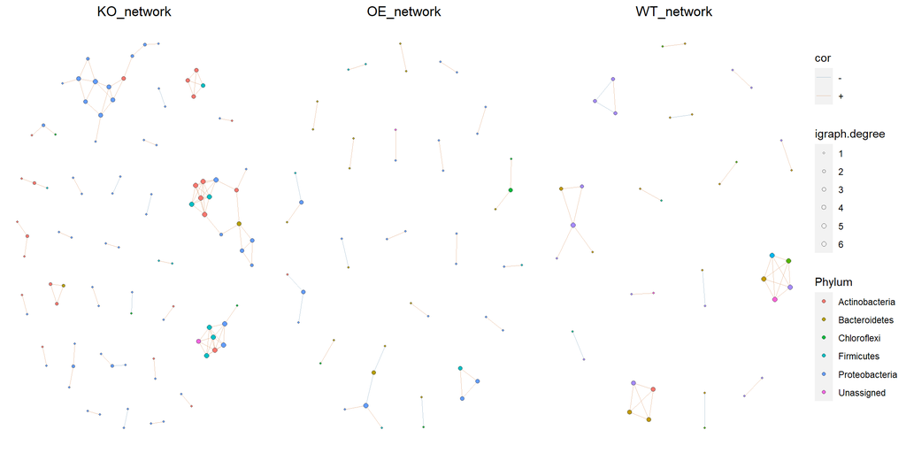

```r
p1 = result[[1]]
p1
```

```r
p5 = result[[5]]
dat = result[[2]]
tablename <- paste(path,"/co-occurrence_Grobel_net",".csv",sep = "")
write.csv(dat,tablename)
```

# 网络稳定性（抗干扰性）

### 模块相似度

```r
#--网络稳定性:模块相似性------
#data(ps)

library(tidyfst)

res = module.compare.m(
    ps = ps,
    Top = 500,
    degree = TRUE,
    zipi = FALSE,
    r.threshold= 0.8,
    p.threshold=0.05,
    method = "spearman",
    padj = F,   # 数据多的话需要设置成T
    n = 3)  # 每个模块超过3个OTU才能算作一个模块
```

```
## [1] 80  8
## [1] 159   8
## [1] 224   8
## [1] 0
## [1] 1
## [1] 2
## [1] 3
## [1] 4
## [1] 0
## [1] 1
## [1] 2
## [1] 3
## [1] 4
## [1] 0
## [1] 1
## [1] 2
## [1] 3
## [1] 4
```

```r
rank_names(ps)
```

```
## [1] "Kingdom" "Phylum"  "Class"   "Order"   "Family"  "Genus"   "Species"
```

```r
taxa_names(ps)
```

[output not shown]

[output cut: 462 more lines]

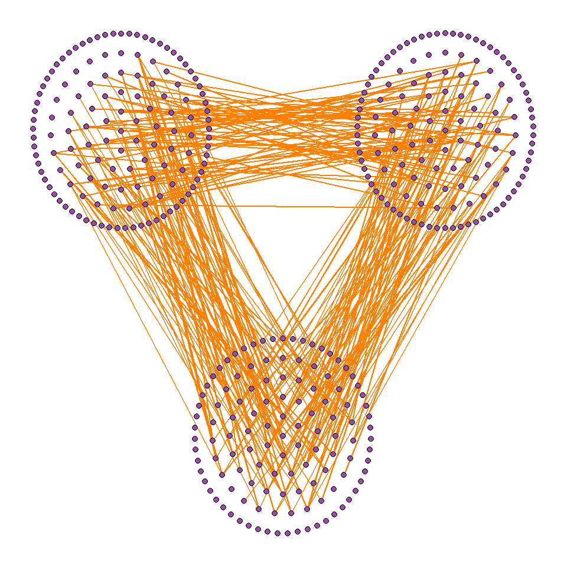

```r
#不同分组使用一个圆圈展示，圆圈内一个点代表一个模块，相连接的模块代表了相似的模块。
pstable = res[[1]]
pstable
```

```r
 #--提取模块的OTU，分组等的对应信息
datstable = res[[2]]
head(datstable)
```

```
##        ID     group Group
## 1 ASV_256 KOmodel_1    KO
## 2 ASV_142 KOmodel_1    KO
## 3 ASV_362 KOmodel_1    KO
## 4  ASV_89 KOmodel_1    KO
## 5 ASV_419 KOmodel_1    KO
## 6 ASV_352 KOmodel_1    KO
```

```r
#模块相似度结果表格
datstable2 = res[[3]]
head(datstable2)
```

```
##                          module1    module2 Both P1A2 P2A1 A1A2
## KOmodel_41-OEmodel_2  KOmodel_41  OEmodel_2    1    2    6  500
## KOmodel_62-OEmodel_1  KOmodel_62  OEmodel_1    1    2    6  500
## KOmodel_34-OEmodel_1  KOmodel_34  OEmodel_1    1    2    6  500
## KOmodel_22-OEmodel_4  KOmodel_22  OEmodel_4    1    3    5  500
## KOmodel_26-OEmodel_8  KOmodel_26  OEmodel_8    1    3    4  501
## KOmodel_17-OEmodel_10 KOmodel_17 OEmodel_10    1    4    4  500
##                                    p_raw              p_adj
## KOmodel_41-OEmodel_2  0.0407716775257314 0.0407716775257314
## KOmodel_62-OEmodel_1  0.0407716775257314 0.0407716775257314
## KOmodel_34-OEmodel_1  0.0407716775257314 0.0407716775257314
## KOmodel_22-OEmodel_4  0.0464588019672787 0.0464588019672787
## KOmodel_26-OEmodel_8  0.0388304723830171 0.0388304723830171
## KOmodel_17-OEmodel_10 0.0483470023594227 0.0483470023594227
```

```r
path_6 = "C:/16S/result/ggclusternet/net_stable/"
dir.create(path_6)

write.table(datstable2,file = "C:/16S/result/ggclusternet/net_stable/simility.txt",quote = F,sep = '\t', row.names = T, col.names = T)
write.table(datstable,file = "C:/16S/result/ggclusternet/net_stable/simility2.txt",quote = F,sep = '\t', row.names = T, col.names = T)
ggsave("C:/16S/result/ggclusternet/net_stable/simility.pdf",pstable,width = 8,height = 7)
```

### 网络鲁棒性（随机去除节点）

这里通过随机去除部分OTU，计算网络鲁棒性，代表网络抗干扰的能力。 按照0.05的步长，每次去除5%的文生物，重新计算鲁棒性，知道最终全部去除。 如果有分组列Group，则会按照分组进行鲁棒性计算，并且区分颜色绘制到一个面板中。 计算鲁棒性这里使用丰度加成权重和不加权两种方式，左边是不加权，后侧是加权的结果。 这里步长不可以修改，因为修改好像也没什么意思。

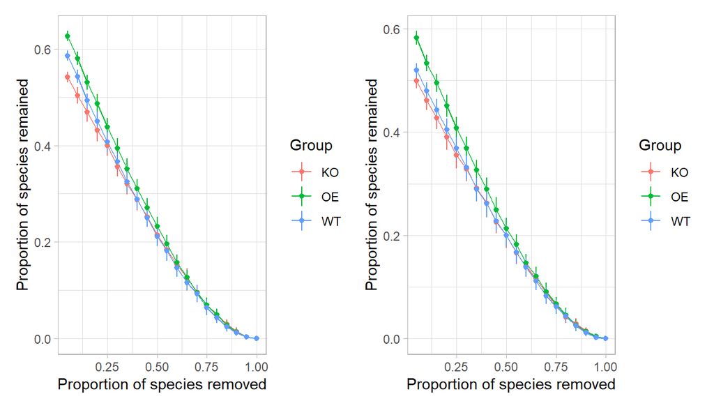

```r
#--随即取出任意比例节点-网络鲁棒性#---------
res = Robustness.Random.removal(ps = ps,
                                Top = 500,
                                r.threshold= 0.8,
                                p.threshold=0.05,
                                method = "spearman"

                                )
pstable3 = res[[1]]
pstable3
```

```r
#提取数据
dats3 = res[[2]]
head(dat3)
```

```
##                           value
## num.edges(L)              "2212"
## num.pos.edges             "2212"
## num.neg.edges             "0"
## num.vertices(n)           "707"
## Connectance(edge_density) "0.00886320926710235"
## average.degree(Average K) "6.25742574257426"
```

```r
write.table(dats3,file = "C:/16S/result/ggclusternet/net_stable/robustness.txt",quote = F,sep = '\t', row.names = T, col.names = T)
ggsave("C:/16S/result/ggclusternet/net_stable/robustness.pdf",pstable3,width = 16,height = 7)
```